# Dissertation Analysis: Time Remaining

Jamiahus Walton

5/6/2019

## Purpose

The purpose of this document is to record the data analysis for my Dissertation.

## Experimental Design

This experiment is a within-subject experimental design. The primary variable was the feedback condition (i.e., Target). There were four feedback conditions; None, Individual, Team, and Ind_Team Each team experienced each condition. The first condition for each group was the None condition. The remaining three conditions were counterbalanced. For example, the condition order for team 7 is the following: None, Ind, Team, Ind_Team. The condition order for group 8 is the following: None, Team, Individual, Ind_Team.

## Data Description

I collected data from **117** participants that formed **39** teams. Below is a sample of the data for the main metrics

|  | TeamScore | IndividualScore | CI_team | CI_ind | II_team | II_ind | ERROR_team_unique | ERROR_ind_unique | ERROR_team_total | ERROR_ind_total |
| --- | --- | --- | --- | --- | --- | --- | --- | --- | --- | --- |
| 4 | 57.8487 | 65.4831 | 18 | 6 | 1 | 0 | 5 | 3 | 42 | 17 |
| 5 | 57.8487 | 56.6639 | 18 | 3 | 1 | 0 | 5 | 2 | 42 | 4 |
| 6 | 57.8487 | 53.6650 | 18 | 5 | 1 | 1 | 5 | 5 | 42 | 21 |
| 7 | 57.5211 | 57.3410 | 18 | 4 | 3 | 2 | 5 | 3 | 34 | 10 |
| 8 | 57.5211 | 49.6867 | 18 | 3 | 3 | 1 | 5 | 4 | 34 | 8 |

## Research Question

This research attempts to answer the following question: *How will teams’ performance change if given feedback that displays indicators based on individual performance, team performance, or both?*

## Exploratory Data Analysis

In this section, I seek to visually discover answers to the research question mentioned above.

### Q: Is there exciting variation among the *Time Remaining* metric that will help me understand the influence of the feedback condition?

#### Team

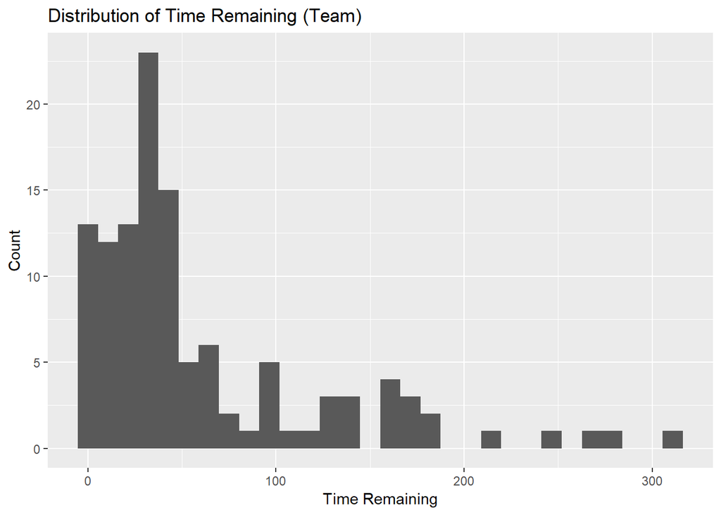

```r
y_label_team <- "Count"
x_label_team <- params$dependent_response_name_WithSpace
title_response_team <- paste("Distribution of", params$dependent_response_name_WithSpace, "(Team)")
plot_name <- paste("Histogram_", params$dependent_response_name_NoSpace, "_Team.png", sep = "")
setwd(figure_directory)

plot_data_team <- team_data %>%
  select(params$dependent_response_team, Target)

ggplot(data = plot_data_team) +
  geom_histogram(aes_string(x = params$dependent_response_team), bins = 30) +
  labs(title = title_response_team, x = x_label_team, y = y_label_team) +
  ggsave(filename = plot_name)
```

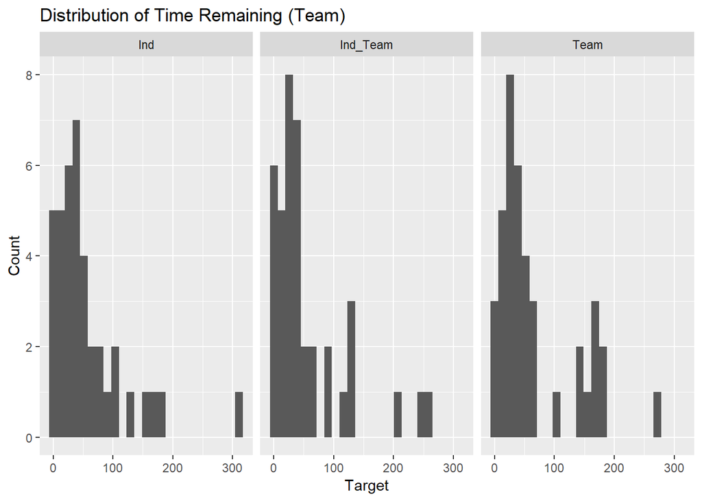

```r
y_label_team <- "Count"
x_label_team <- "Target"
title_response_team <- paste("Distribution of", params$dependent_response_name_WithSpace, "(Team)")
plot_name <- paste("Histogram_", params$dependent_response_name_NoSpace, "_ByTarget_Team.png", sep = "")
setwd(figure_directory)

plot_data_team <- team_data %>%
  select(params$dependent_response_team, Target)

ggplot(data = plot_data_team) +
  geom_histogram(aes_string(x = params$dependent_response_team), bins = 25) +
  facet_grid(. ~ Target) +
  labs(title = title_response_team, x = x_label_team, y = y_label_team) +
  ggsave(filename = plot_name)
```

```r
# Information about the N values in each condition
tableData <- team_data %>%
  group_by(Target) %>%
  summarise(N = length(.data[[params$dependent_response_team]]))

tableData %>%
  kable() %>%
  kable_styling()
```

| Target | N |
| --- | --- |
| Ind | 39 |
| Ind_Team | 39 |
| Team | 39 |

**Reflection:** The skewness in the time remaining data at the team level centers around 50 seconds or so. This skewness suggests that most of the teams had about the same amount of time remaining at the end of the session (50 or 40 seconds). In other words, there is no obvious pattern visually.

#### Individual

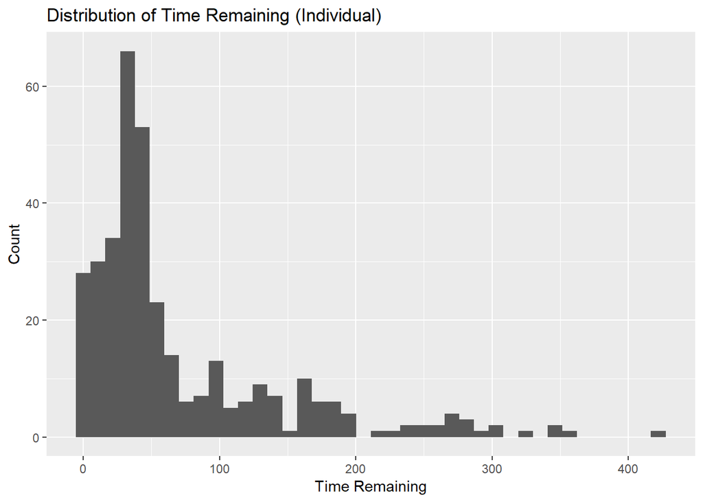

```r
y_label_ind <- "Count"
x_label_ind <- params$dependent_response_name_WithSpace
title_response_ind <- paste("Distribution of", params$dependent_response_name_WithSpace, "(Individual)")
plot_name <- paste("Histogram_", params$dependent_response_name_NoSpace, "_Ind.png", sep = "")
setwd(figure_directory)

plot_data_ind <- ind_data %>%
  select(params$dependent_response_ind, Target)

ggplot(data = plot_data_ind) +
  geom_histogram(aes_string(x = params$dependent_response_ind), bins = 40) +
  labs(title = title_response_ind, x = x_label_ind, y = y_label_ind) +
  ggsave(filename = plot_name)
```

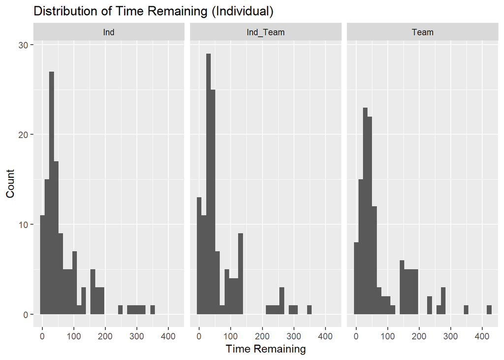

```r
y_label_ind <- "Count"
x_label_ind <- params$dependent_response_name_WithSpace
title_response_ind <- paste("Distribution of", params$dependent_response_name_WithSpace, "(Individual)")
plot_name <- paste("Histogram_", params$dependent_response_name_NoSpace, "_ByTarget_Ind.png", sep = "")
setwd(figure_directory)

plot_data_ind <- ind_data %>%
  select(params$dependent_response_ind, Target)

ggplot(data = plot_data_ind) +
  geom_histogram(aes_string(x = params$dependent_response_ind), bins = 30) +
  facet_grid(. ~ Target) +
  labs(title = title_response_ind, x = x_label_ind, y = y_label_ind) +
  ggsave(filename = plot_name)
```

```r
# Information about the N values in each condition
tableData <- ind_data %>%
  group_by(Target) %>%
  summarise(N = length(.data[[params$dependent_response_ind]]))

tableData %>%
  kable() %>%
  kable_styling()
```

| Target | N |
| --- | --- |
| Ind | 117 |
| Ind_Team | 117 |
| Team | 117 |

The distribution for each condition is similar to the overall data distribution. This similarity tells me that most individuals finished with about 50 seconds or so left at the end of each session.

**Reflection:** It seems as though we can say the high performing individuals finished with over 50 seconds or so left at the end of the session. Do high performing individuals have similar characteristics? How should we define a “high performing” individual? Overall, the distribution at the team level is similar to the distribution at the team level.

#### Summary / Reflection

There did not seem to be any obvious pattern when grouping the data by Feedback conditions. Maybe the feedback conditions influenced the amount of time remaining depending on their experience (i.e., session order)?

### Q: Is there exciting variation among the *Time Remaining* that explains how the feedback conditions influence the *Time Remaining* when session order is taken into consideration?

#### Team

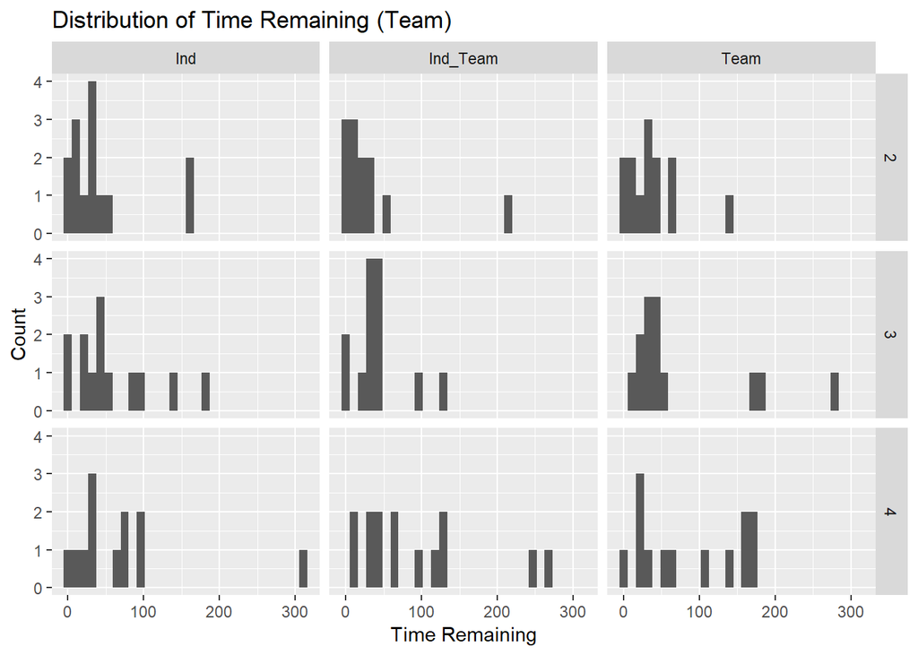

```r
y_label_team <- "Count"
x_label_team <- params$dependent_response_name_WithSpace
title_response_team <- paste("Distribution of", params$dependent_response_name_WithSpace, "(Team)")
plot_name <- paste("Histogram_", params$dependent_response_name_NoSpace, "_ByTarget_BySessionOrder_Team.png", sep = "")
setwd(figure_directory)

plot_data_team <- team_data %>%
  select(params$dependent_response_team, Target, SessionOrder)

ggplot(data = plot_data_team) +
  geom_histogram(aes_string(x = params$dependent_response_team), bins = 30) +
  labs(title = title_response_team, x = x_label_team, y = y_label_team) +
  facet_grid( SessionOrder ~ Target) +
  ggsave(filename = plot_name)
```

```r
# Information about the N values in each condition
tableData <- team_data %>%
  select(params$dependent_response_team, Target, SessionOrder) %>%
  group_by(Target, SessionOrder) %>%
  summarise(N = length(.data[[params$dependent_response_team]]))

tableData %>%
  kable() %>%
  kable_styling()
```

| Target | SessionOrder | N |
| --- | --- | --- |
| Ind | 2 | 14 |
| Ind | 3 | 13 |
| Ind | 4 | 12 |
| Ind_Team | 2 | 12 |
| Ind_Team | 3 | 13 |
| Ind_Team | 4 | 14 |
| Team | 2 | 13 |
| Team | 3 | 13 |
| Team | 4 | 13 |

It looks like the distribution for time remaining for the Ind_Team condition seems to spread (or flatten) over time, which means that the teams were completing the task faster with more experience.

It looks like the distribution of the amount of time remaining at the end of the session in the team feedback condition starts to spread over time.

The distribution for the Ind_Team and Team condition seem to spread (i.e., flatten) over time instead of moving from let to right. To me, this suggest that there are some time that get better with time in these conditions and there are other teams that do no get better with time.

#### Individual

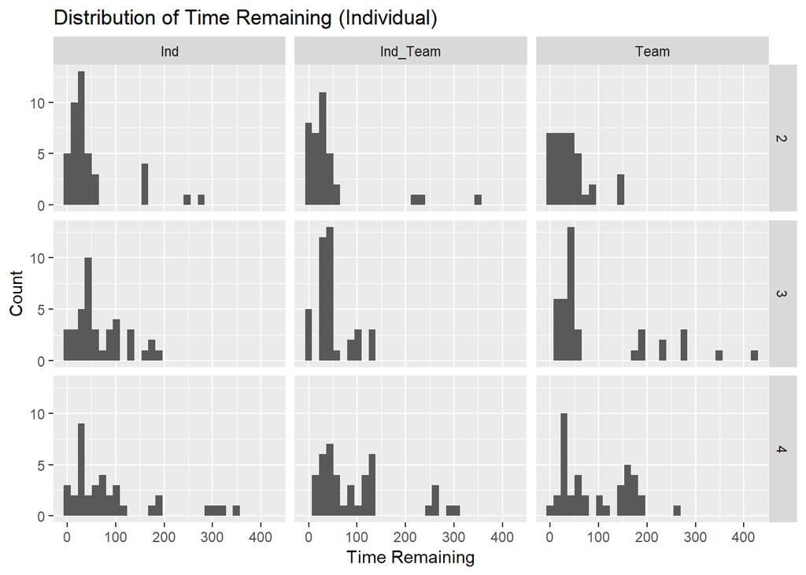

```r
y_label_ind <- "Count"
x_label_ind <- params$dependent_response_name_WithSpace
title_response_ind <- paste("Distribution of", params$dependent_response_name_WithSpace, "(Individual)")
plot_name <- paste("Histogram_", params$dependent_response_name_NoSpace, "_ByTarget_BySessionOrder_Ind.png", sep = "")
setwd(figure_directory)

plot_data_ind <- ind_data %>%
  select(params$dependent_response_ind, Target, SessionOrder)

ggplot(data = plot_data_ind) +
  geom_histogram(aes_string(x = params$dependent_response_ind), bins = 30) +
  facet_grid(SessionOrder ~ Target) +
  labs(title = title_response_ind, x = x_label_ind, y = y_label_ind) +
  ggsave(filename = plot_name)
```

```r
# Information about the N values in each condition
tableData <- ind_data %>%
  select(params$dependent_response_ind, Target, SessionOrder) %>%
  group_by(Target, SessionOrder) %>%
  summarise(N = length(.data[[params$dependent_response_ind]]))

tableData %>%
  kable() %>%
  kable_styling()
```

| Target | SessionOrder | N |
| --- | --- | --- |
| Ind | 2 | 42 |
| Ind | 3 | 39 |
| Ind | 4 | 36 |
| Ind_Team | 2 | 36 |
| Ind_Team | 3 | 39 |
| Ind_Team | 4 | 42 |
| Team | 2 | 39 |
| Team | 3 | 39 |
| Team | 4 | 39 |

**Reflection:** I am getting the sense that the individual condition did not influence how quickly the participants completed the session. In other words, giving the individual feedback on performance metrics did not encourage the participants to move faster through the session. However, it looks like the distrabution of the time remaining flattens when groups are given Team or Ind_Team feedback. This tells me that teams are more likely to move through the task quicker if given Ind_Team or Team feedback, not individual feedback.

#### Summary / Reflection

Overall, the distribution is telling me that over time, teams move through the task quicker when given Team or Ind_Team feedback but not individual feedback. This suggests that if I looked at the fourth session and group the data by the feedback conditions, I would see that the time remaining in the Ind_Team and Team condition would be different from the time remaining in the individual condition.

### Q: Is there an *interaction* between the Target and Session Order for the *Time Remaining*?

I am interested in this question for modeling purposes. I want to know if I need to include the interaction between Target and Session Order.

#### Team

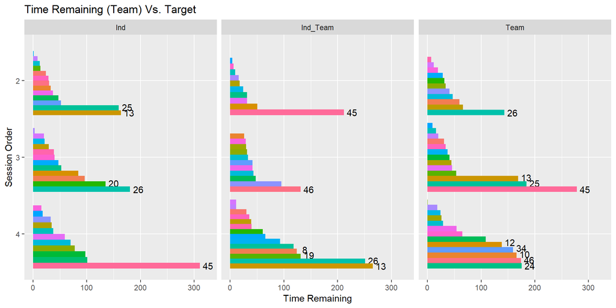

```r
y_label_team <- params$dependent_response_name_WithSpace
x_label_team <- "Session Order"
title_response_team <- paste(params$dependent_response_name_WithSpace, "(Team) Vs. Target")
value_threshold <- 120
plot_name <- paste("Bar_", params$dependent_response_name_NoSpace, "_ByTarget_BySessionOrder_Team.png", sep = "")
setwd(figure_directory)

plot_data_team <- team_data %>%
  select(Target, SessionOrder, params$dependent_response_team, Team) %>%
  mutate(rank_order = -rank(team_data[[params$dependent_response_team]], ties.method = "first")) %>%
  mutate(above_value_threshold = .data[[params$dependent_response_team]] > value_threshold)

names <- ifelse(plot_data_team[,"above_value_threshold"], as.character( plot_data_team[["Team"]]), "")

ggplot(data = plot_data_team,
       aes(x = factor(SessionOrder),
                  y = .data[[params$dependent_response_team]],
                  fill = Team,
                  group = rank_order,
                  label = names )) +
  geom_text(position = position_dodge(1), vjust = 0, aes(y = .data[[params$dependent_response_team]] + 15), check_overlap = FALSE) +
  geom_bar(stat = "identity", position = "dodge") +
  facet_grid(. ~ Target) +
  guides(fill = FALSE) +
  coord_flip()+
  xlim("4", "3", "2") +
  labs(y = y_label_team, x = x_label_team, title = title_response_team, fill = "Teams") +
  ggsave(filename = plot_name)
```

```r
sumDataCount <- plot_data_team %>%
  group_by(Target, SessionOrder) %>%
  summarise(N = length(.data[[params$dependent_response_team]]))

sumDataCount %>%
  kable() %>%
  kable_styling()
```

| Target | SessionOrder | N |
| --- | --- | --- |
| Ind | 2 | 14 |
| Ind | 3 | 13 |
| Ind | 4 | 12 |
| Ind_Team | 2 | 12 |
| Ind_Team | 3 | 13 |
| Ind_Team | 4 | 14 |
| Team | 2 | 13 |
| Team | 3 | 13 |
| Team | 4 | 13 |

Visually, the first thing that jumps out to me that there seem to be a few outliers that may be influencing the results.

Let’s call a group “fast” if that group has more than 120 seconds left at the end of the session. The teams that are labeled had more than 120 seconds (2 minutes) remaining at the end of the session. This value is an arbitrary value.

The groups that are labeled in all the conditions (Target levels) are team 26, 45, 13. Some of these teams data may be outliers.

**Reflection:** This figure tells me that I may need to consider removing these teams because they may be outliers. However, I do not have a good reason to remove the values. Instead, I considered teams, that seemed to be outliers, fast teams. These are the teams that had more than 120 seconds (2 minutes) remaining. If I want to look at the characterisitics of fast groups, I could use teams 13, 26, and 45 as fast moving teams.

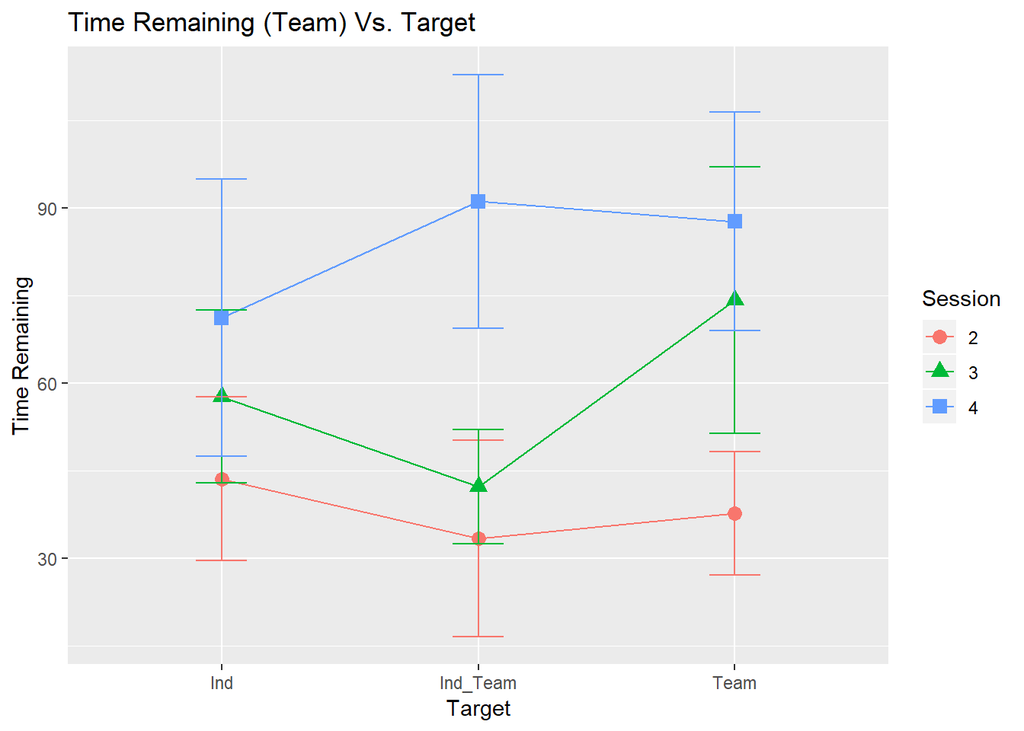

```r
y_label_team <- params$dependent_response_name_WithSpace
x_label_team <- "Target"
title_response_team <- paste(params$dependent_response_name_WithSpace, "(Team) Vs. Target")
plot_name <- paste("InteractionPlot_", params$dependent_response_name_NoSpace, "_ByTarget_BySessionOrder_Team.png", sep = "")
setwd(figure_directory)

plot_data_team <- team_data %>%
  select(Target, SessionOrder, params$dependent_response_team) %>%
  group_by(SessionOrder, Target) %>%
  summarise(dependentAverage = mean(.data[[params$dependent_response_team]]),
            Stdv =sd(.data[[params$dependent_response_team]]), n = length(.data[[params$dependent_response_team]]),
            StEr = sd(.data[[params$dependent_response_team]]) / sqrt(length(.data[[params$dependent_response_team]])))

ggplot(data = plot_data_team, aes(x = Target, y = dependentAverage, color = SessionOrder, shape = SessionOrder)) +
  geom_point(size = 3) +
  geom_line(aes(group=SessionOrder, color = SessionOrder)) +
  geom_errorbar(aes(ymin = dependentAverage - StEr, ymax = dependentAverage + StEr), width = 0.2) +
  labs(y = y_label_team, x = x_label_team, title = title_response_team, color = "Session", shape = "Session") +
  ggsave(filename = plot_name)
```

Visually, there appears to be some level of interaction between Target and SessionOrder for the time remaining. The interaction does not seem to be strong. The graph suggests that the average time remaining at the end of the session increases over time. The increase is particularly noticeable in the Ind_Team condition going from session 3 to session 4. In other words, when given Ind_Team feedback, the amount of time remaining at the end of each session increases faster.

**Reflection:** There seems to be some level of interaction but I am getting the sense that it is not a strong interaction. I’ll have to run statistical tests to examine the strength of the effect to determine if there is an interaction effect.

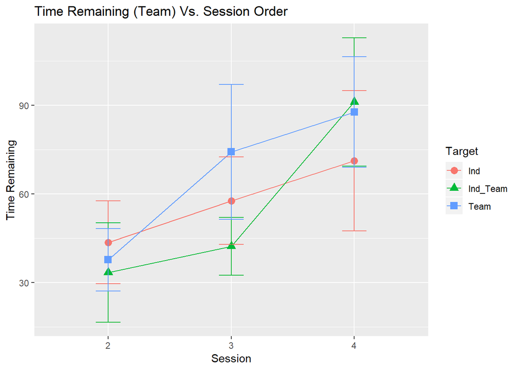

```r
y_label_team <- params$dependent_response_name_WithSpace
x_label_team <- "Session"
title_response_team <- paste(params$dependent_response_name_WithSpace, "(Team) Vs. Session Order")
plot_name <- paste("InteractionPlot_", params$dependent_response_name_NoSpace, "_BySessionOrder_ByTarget_Team.png", sep = "")
setwd(figure_directory)

plot_data_team <- team_data %>%
  select(Target, SessionOrder, params$dependent_response_team) %>%
  group_by(SessionOrder, Target) %>%
  summarise(DependentAverage = mean(.data[[params$dependent_response_team]]),
            Stdv =sd(.data[[params$dependent_response_team]]), n = length(.data[[params$dependent_response_team]]),
            StEr = sd(.data[[params$dependent_response_team]]) / sqrt(length(.data[[params$dependent_response_team]])))

ggplot(data = plot_data_team, aes(x = SessionOrder , y = DependentAverage, color = Target, shape = Target)) +
  geom_point(size = 3) +
  geom_line(aes(group=Target, color = Target)) +
  geom_errorbar(aes(ymin = DependentAverage - StEr, ymax = DependentAverage + StEr), width = 0.2) +
  labs(y = y_label_team, x = x_label_team, title = title_response_team, color = "Target", shape = "Target") +
  ggsave(filename = plot_name)
```

There appears to be an interaction between the Target and Session Order variable. This figure tells me that over time the amount of time remaining at the end of each session increases over time. This figure tells me that in the different session orders, the amount of time remaining is roughly the same in after 4 sessions. However, over time, the amount of time remaining at the end of the session changes differently depending on the feedback condition.

The individual session steadily improves over time.

The Individual_Team session has a small improvement from session 2 to session 3, but there is a substantial increase from session 3 to session 4. This tells me that for some reason there was little change between session 2 and session 3, but something happened that caused a major improvement from session 3 to session 4.

The team session showed a substantial increase from session 2 to 3 but a small improvement from session 3 to session 4. This suggests that for some reason there was a major improvement between session 2 and session 3, but there was little gain between session 3 and session 4. This could mean that the feedback was no longer useful between 3 and 4 or that the teams reached their highest performance.

**Reflection:** I am getting the session that the team condition encouraged teams to move quicker through the session. There was a substantial increase in the amount of time remaining at the end of the session in the Team condition when moving from session 2 to session 3. I am also getting the sense that the Ind_Team feedback condition may be encouraging a team to move quicker through the task as well. However, it looks like the effect of the Ind_Team feedback takes longer to take effect. Even so, the amount of time remaining at the end of the session ended up being about the same after four sessions in the Ind_Team and the Team condition.

#### Individual

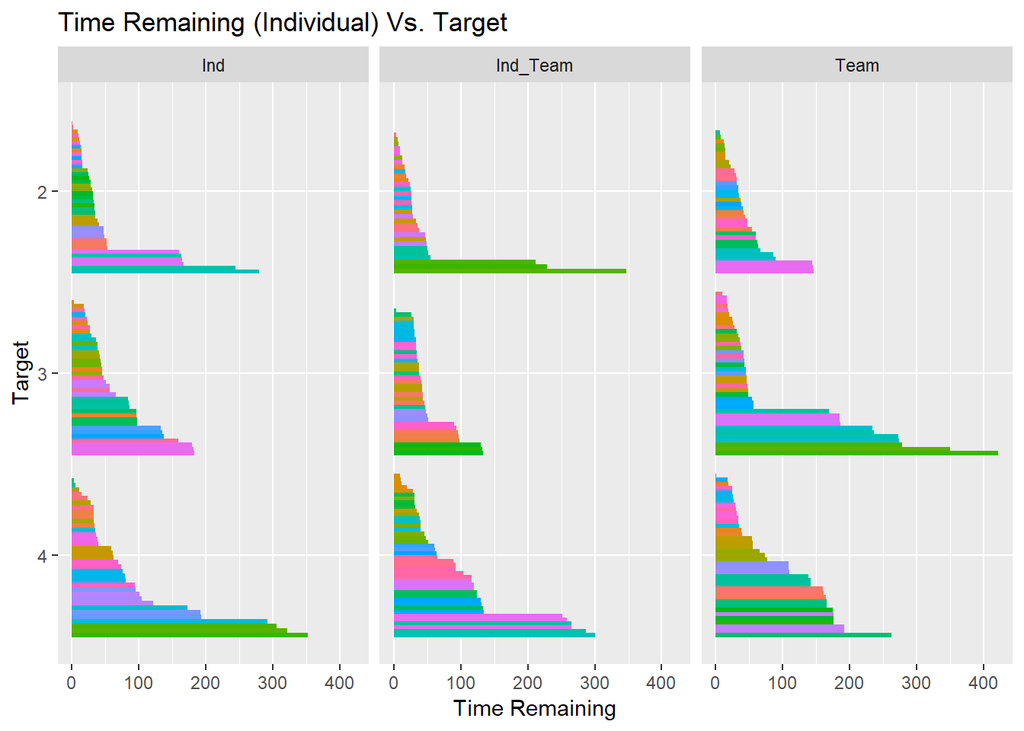

```r
y_label_ind <- params$dependent_response_name_WithSpace
x_label_ind <- "Target"
title_response_ind <- paste(params$dependent_response_name_WithSpace,"(Individual) Vs. Target")
value_threshold <- 120
plot_name <- paste("Bar_", params$dependent_response_name_NoSpace, "_ByTarget_BySessionOrder_Ind.png", sep = "")
setwd(figure_directory)

plot_data_ind <- ind_data %>%
  select(Target, SessionOrder, params$dependent_response_ind, Player_ID) %>%
  mutate(rank_order = -rank(.data[[params$dependent_response_ind]])) %>%
  mutate(above_value_threshold = .data[[params$dependent_response_ind]] > value_threshold)

names <- ifelse(plot_data_ind[,"above_value_threshold"], as.character( plot_data_ind[["Player_ID"]]), "")

ggplot(data = plot_data_ind,
       aes(x = factor(SessionOrder),
                  y = .data[[params$dependent_response_ind]],
                  fill = Player_ID, group = rank_order,
                  label = names )) +
  geom_bar(stat = "identity", position = "dodge") +
  facet_grid(. ~ Target) +
  guides(fill = FALSE) +
  coord_flip()+
  xlim("4", "3", "2") +
  labs(y = y_label_ind, x = x_label_ind, title = title_response_ind, fill = "Player_ID") +
  ggsave(filename = plot_name)
```

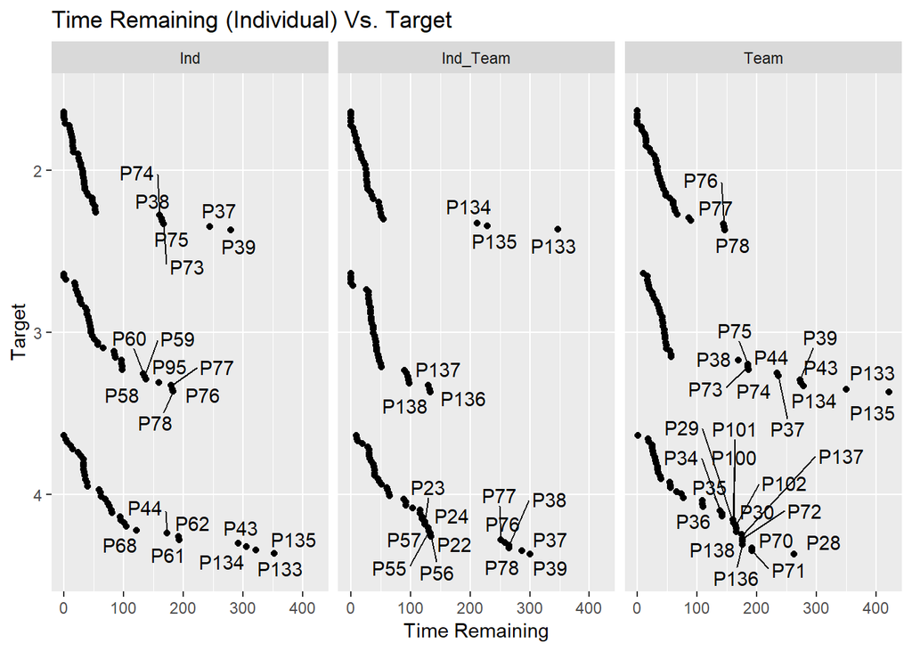

```r
ggplot(data = plot_data_ind,
       aes(x = factor(SessionOrder),
           y = .data[[params$dependent_response_ind]],
           fill = Player_ID, group = rank_order,
           label = names )) +
  geom_text_repel(stat = "identity", position = position_jitterdodge(), force = 5) +
  geom_point(position = position_jitterdodge()) +
  facet_grid(. ~ Target) +
  guides(fill = FALSE) +
  coord_flip()+
  xlim("4", "3", "2") +
  labs(y = y_label_ind, x = x_label_ind, title = title_response_ind, fill = "Player ID") +
  ggsave(filename = paste("Point_", params$dependent_response_name_NoSpace, "_ByTarget_BySessionOrder_Ind.png", sep = ""), width = 10)
```

```r
sumDataCount <- plot_data_ind %>%
  group_by(Target, SessionOrder) %>%
  summarise(N = length(.data[[params$dependent_response_ind]]))

sumDataCount %>%
  kable() %>%
  kable_styling()
```

| Target | SessionOrder | N |
| --- | --- | --- |
| Ind | 2 | 42 |
| Ind | 3 | 39 |
| Ind | 4 | 36 |
| Ind_Team | 2 | 36 |
| Ind_Team | 3 | 39 |
| Ind_Team | 4 | 42 |
| Team | 2 | 39 |
| Team | 3 | 39 |
| Team | 4 | 39 |

```r
sumCountFastParticipants <- plot_data_ind %>%
  filter(above_value_threshold) %>%
  group_by(Target, SessionOrder) %>%
  summarise(N_fast = length(.data[[params$dependent_response_ind]]))

sumCountFastParticipants %>%
  kable() %>%
  kable_styling()
```

| Target | SessionOrder | N_fast |
| --- | --- | --- |
| Ind | 2 | 6 |
| Ind | 3 | 7 |
| Ind | 4 | 8 |
| Ind_Team | 2 | 3 |
| Ind_Team | 3 | 3 |
| Ind_Team | 4 | 12 |
| Team | 2 | 3 |
| Team | 3 | 11 |
| Team | 4 | 15 |

Visually, it looks like some participants moved quickly through the task (i.e., possible outliers). It seems like there are more “fast” participants in session for in the Team condition.

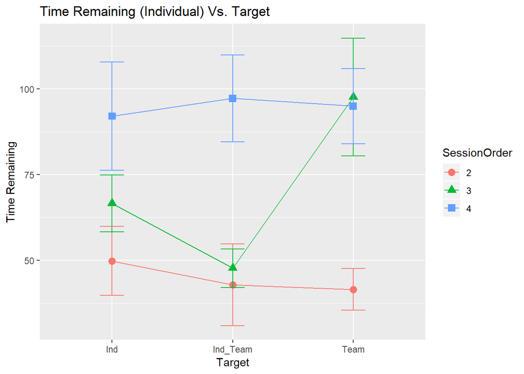

```r
y_label_ind <- params$dependent_response_name_WithSpace
x_label_ind <- "Target"
title_response_ind <- paste(params$dependent_response_name_WithSpace, "(Individual) Vs. Target")
plot_name <- paste("InteractionPlot_", params$dependent_response_name_NoSpace, "_ByTarget_BySessionOrder_Ind.png", sep = "")
setwd(figure_directory)

plot_data_ind <- ind_data %>%
  select(Target, SessionOrder, params$dependent_response_ind) %>%
  group_by(SessionOrder, Target) %>%
  summarise(Average = mean(.data[[params$dependent_response_ind]]),
            Stdv =sd(.data[[params$dependent_response_ind]]),
            n = length(.data[[params$dependent_response_ind]]),
            StEr = sd(.data[[params$dependent_response_ind]]) / sqrt(length(.data[[params$dependent_response_ind]])))

ggplot(data = plot_data_ind, aes(x = Target, y = Average, color = SessionOrder, shape=SessionOrder)) +
  geom_point(size = 3) +
  geom_line(aes(group=SessionOrder, color = SessionOrder)) +
  geom_errorbar(aes(ymin = Average - StEr, ymax = Average + StEr), width = 0.2) +
  labs(y = y_label_ind, x = x_label_ind, title = title_response_ind, fill = "Players") +
  ggsave(filename = plot_name)
```

There appears to be an interaction between Target and Session Order. Overall, the amount of time at the end of the session increases over time. It looks like there is a considerable increase in the amount of time remaining in the Team condition from Session 2 to session 3. This substantial increase suggests that giving team feedback resulted in individuals moving faster. It looks like something is happening in the Team and Ind_Team condition. In the Ind condition, there is a steady increase in the amount of time remaining. In the Ind_Team condition, there was little to no change in the time remaining between session 2 and 3 but a big change from session 3 to 4.

**Reflection:** I am getting the sense that something is happening with the Ind_Team and the Team condition. For some reason, there are these large increases in the time remaining.

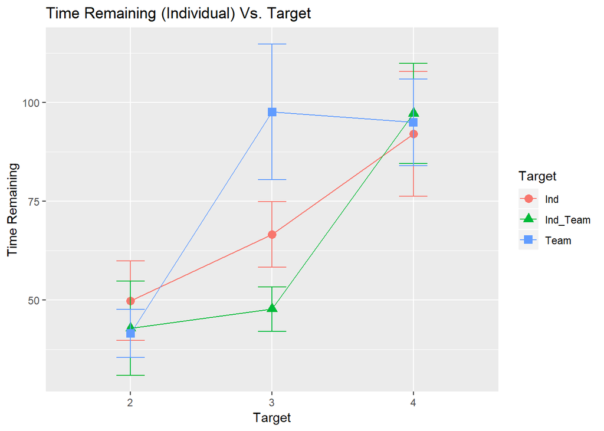

```r
y_label_ind <- params$dependent_response_name_WithSpace
x_label_ind <- "Target"
title_response_ind <- paste(params$dependent_response_name_WithSpace, "(Individual) Vs. Target")
plot_name <- paste("InteractionPlot_", params$dependent_response_name_NoSpace, "_BySessionOrder_ByTarget_Ind.png", sep = "")
setwd(figure_directory)

plot_data_ind <- ind_data %>%
  select(Target, SessionOrder, params$dependent_response_ind) %>%
  group_by(SessionOrder, Target) %>%
  summarise(Average = mean(.data[[params$dependent_response_ind]]),
            Stdv =sd(.data[[params$dependent_response_ind]]),
            n = length(.data[[params$dependent_response_ind]]),
            StEr = sd(.data[[params$dependent_response_ind]]) / sqrt(length(.data[[params$dependent_response_ind]])))

ggplot(data = plot_data_ind, aes(x = SessionOrder, y = Average, color = Target, shape=Target)) +
  geom_point(size = 3) +
  geom_line(aes(group=Target, color = Target)) +
  geom_errorbar(aes(ymin = Average - StEr, ymax = Average + StEr), width = 0.2) +
  labs(y = y_label_ind, x = x_label_ind, title = title_response_ind, fill = "Players") +
  ggsave(filename = plot_name)
```

There seems to be an interaction between the session order and the target variable.

In the Ind condition, there is a steadying increase in the time remaining at the individual level.

In the Team condition, there is a large improvement from session 2 to session 3 but little to no improvement from session 3 to session 4.

In the Ind_Team condition, there is little to no improvement from session 2 to session 3 but a large improvement from session 3 to session 4.

**Reflection:** I get the sense that something interesting is going on with the Ind_Team and Team conditions. The figure suggests that both sessions have a positive influence (i.e., increase the amount of time remaining) on how fast participants move through the session. It seems as though the positive effect of the Team condition happens quicker than the impact of the Ind_Team condition.

#### Summary / Reflection

I am getting the sense that there is something interesting happening with the Ind_Team condition and Team condition. For some reason, the positive effect (i.e., the large increase in the time remaining at the end of the session) in the Team condition happens quicker than the positive effect from the Ind_Team condition. More exploration is needed to understand why this apparent effect is happening. Some statistical analysis is necessary to determine the strength of this effect if it exists. Also, statistical tests are needed to determine if there is an interaction between the Target and SessionOrder variable for the individual and team level.

### Q: Is there an interaction between the Target and Session Order for the *Time Remaining* that is statistically significant?

I am interested in determining if a linear mixed effect model should include the interaction effect between the Target and Session Order variable.

A note on the effect size ($R^2$). This method generates two types of ($R^2$) values called marginal ($R_{m}^2$) and conditional ($R_{c}^2$) effect size. The $R_{m}^2$ calculates how much of the variance is described by the fixed effect variables (feedback condition and session order) while the $R_{c}^2$ calculates how much of the variance is described by both the fixed and random effect variables.

#### Full Models Used for Team and Individual

The next two sections below describe the full model for team and individual level analysis. Five models were fitted and then compared. One model was the null model, one model was the full model, and the last three are a subset of the full model.

##### Team Full Model

$$y_{ijt} = \mu + \alpha_{i} + \beta_{j} + \alpha_{i} \beta_{j} + \gamma_{t} + \epsilon_{ijt}$$

##### Individual Team Full Model

$$y_{ijtp} = \mu + \alpha_{i} + \beta_{j} + \alpha_{i} \beta_{j} + \gamma_{t} + \theta_{p} + \epsilon_{ijtp}$$

#### Team

```r
# Data to fit
data_modified_team <- team_data %>%
  select(TeamScore,
         params$dependent_response_team,
         Target,
         SessionOrder,
         Team)

# Generate models with variable response
data_focus_team <- data_modified_team
model.null <- model_data_Target_Session(df = data_focus_team, dependent =  params$dependent_response_team, model.type =  "null", is.team = TRUE, is.robust =FALSE)
model.All <- model_data_Target_Session(df = data_focus_team, dependent =  params$dependent_response_team, model.type =  "All", is.team = TRUE, is.robust = FALSE)
model.NoInteraction <- model_data_Target_Session(df = data_focus_team, dependent =  params$dependent_response_team, model.type =  "NoInteraction", is.team = TRUE, is.robust = FALSE)
model.NoInteraction.NoTarget <- model_data_Target_Session(df = data_focus_team, dependent =  params$dependent_response_team, model.type =  "NoInteraction_NoTarget", is.team = TRUE, is.robust = FALSE)
model.NoInteraction.NoSession <- model_data_Target_Session(df = data_focus_team, dependent =  params$dependent_response_team, model.type =  "NoInteraction_NoSession", is.team = TRUE, is.robust = FALSE)

# There is an option to compare all the models with the anova(). However, the function does not compare all models to model.null
anova(model.null,
      model.All) %>%
  kable(caption = "ANOVA: Null and All") %>%
  kable_styling()
```

ANOVA: Null and All

|  | Df | AIC | BIC | logLik | deviance | Chisq | Chi Df | Pr(>Chisq) |
| --- | --- | --- | --- | --- | --- | --- | --- | --- |
| model.null | 3 | 1262.402 | 1270.688 | -628.2010 | 1256.402 | NA | NA | NA |
| model.All | 11 | 1238.671 | 1269.055 | -608.3354 | 1216.671 | 39.73105 | 8 | 3.6e-06 |

```r
anova(model.null,
      model.NoInteraction) %>%
  kable(caption = "ANOVA: Null and No.Interaction") %>%
  kable_styling()
```

ANOVA: Null and No.Interaction

|  | Df | AIC | BIC | logLik | deviance | Chisq | Chi Df | Pr(>Chisq) |
| --- | --- | --- | --- | --- | --- | --- | --- | --- |
| model.null | 3 | 1262.402 | 1270.688 | -628.2010 | 1256.402 | NA | NA | NA |
| model.NoInteraction | 7 | 1232.756 | 1252.091 | -609.3779 | 1218.756 | 37.64602 | 4 | 1e-07 |

```r
anova(model.null,
      model.NoInteraction.NoTarget) %>%
  kable(caption = "ANOVA: Null and No.Interaction.No.Target") %>%
  kable_styling()
```

ANOVA: Null and No.Interaction.No.Target

|  | Df | AIC | BIC | logLik | deviance | Chisq | Chi Df | Pr(>Chisq) |
| --- | --- | --- | --- | --- | --- | --- | --- | --- |
| model.null | 3 | 1262.402 | 1270.688 | -628.2010 | 1256.402 | NA | NA | NA |
| model.NoInteraction.NoTarget | 5 | 1231.502 | 1245.313 | -610.7509 | 1221.502 | 34.90007 | 2 | 0 |

```r
anova(model.null,
      model.NoInteraction.NoSession) %>%
  kable(caption = "ANOVA: Null and No.Interaction.No.Session") %>%
  kable_styling()
```

ANOVA: Null and No.Interaction.No.Session

|  | Df | AIC | BIC | logLik | deviance | Chisq | Chi Df | Pr(>Chisq) |
| --- | --- | --- | --- | --- | --- | --- | --- | --- |
| model.null | 3 | 1262.402 | 1270.688 | -628.2010 | 1256.402 | NA | NA | NA |
| model.NoInteraction.NoSession | 5 | 1264.714 | 1278.525 | -627.3571 | 1254.714 | 1.687639 | 2 | 0.4300648 |

The following models were significantly different from the null model: model.All, model.NoInteraction, model.NoInteraction.NoTarget.

model.All: Session Order, Target, and the interaction are included in this model.

model.NoInteraction: Session order and target are the fixed effects in this model.

model.NoInteraction.NoTarget: Session order is the only fixed effect in this model.

I want to compare the models that are significanntly different from the null model (i.e., the models mentioned above) and compare them with one another. The goal is to see if the extra terms improve the model.

```r
# Data to fit
data_modified_team <- team_data %>%
  select(TeamScore,
         params$dependent_response_team,
         Target,
         SessionOrder,
         Team)

# Generate models with variable response
data_focus_team <- data_modified_team
model.All <- model_data_Target_Session(df = data_focus_team, dependent =  params$dependent_response_team, model.type =  "All", is.team = TRUE, is.robust = FALSE)
model.NoInteraction <- model_data_Target_Session(df = data_focus_team, dependent =  params$dependent_response_team, model.type =  "NoInteraction", is.team = TRUE, is.robust = FALSE)
model.NoInteraction.NoTarget <- model_data_Target_Session(df = data_focus_team, dependent =  params$dependent_response_team, model.type =  "NoInteraction_NoTarget", is.team = TRUE, is.robust = FALSE)

# Compare all of the models
anova(model.All,
      model.NoInteraction) %>%
  kable(caption = "ANOVA: model.All and model.NoInteraction") %>%
  kable_styling()
```

```
## refitting model(s) with ML (instead of REML)
```

ANOVA: model.All and model.NoInteraction

|  | Df | AIC | BIC | logLik | deviance | Chisq | Chi Df | Pr(>Chisq) |
| --- | --- | --- | --- | --- | --- | --- | --- | --- |
| model.NoInteraction | 7 | 1232.756 | 1252.091 | -609.3779 | 1218.756 | NA | NA | NA |
| model.All | 11 | 1238.671 | 1269.055 | -608.3354 | 1216.671 | 2.085021 | 4 | 0.7201248 |

```r
anova(model.All,
      model.NoInteraction.NoTarget) %>%
  kable(caption = "ANOVA: model.All and model.NoInteraction.NoTarget") %>%
  kable_styling()
```

```
## refitting model(s) with ML (instead of REML)
```

ANOVA: model.All and model.NoInteraction.NoTarget

|  | Df | AIC | BIC | logLik | deviance | Chisq | Chi Df | Pr(>Chisq) |
| --- | --- | --- | --- | --- | --- | --- | --- | --- |
| model.NoInteraction.NoTarget | 5 | 1231.502 | 1245.313 | -610.7509 | 1221.502 | NA | NA | NA |
| model.All | 11 | 1238.671 | 1269.055 | -608.3354 | 1216.671 | 4.830972 | 6 | 0.565668 |

```r
anova(model.NoInteraction,
      model.NoInteraction.NoTarget) %>%
  kable(caption = "ANOVA: model.NoInteraction and model.NoInteraction.NoTarget") %>%
  kable_styling()
```

```
## refitting model(s) with ML (instead of REML)
```

ANOVA: model.NoInteraction and model.NoInteraction.NoTarget

|  | Df | AIC | BIC | logLik | deviance | Chisq | Chi Df | Pr(>Chisq) |
| --- | --- | --- | --- | --- | --- | --- | --- | --- |
| model.NoInteraction.NoTarget | 5 | 1231.502 | 1245.313 | -610.7509 | 1221.502 | NA | NA | NA |
| model.NoInteraction | 7 | 1232.756 | 1252.091 | -609.3779 | 1218.756 | 2.745951 | 2 | 0.2533519 |

The results show that the model with the interaction (i.e., Model.All) was not significantly better at describing the data than the other two models (*i.e.,model.NoInteraction.NoTarget and model.NoInteraction*). According to this result, we can remove the interaction effect of the model. It is important to note that some models, compared to model.All, have a small difference in AIC values. However, there is a noticeable difference in BIC values.

The results also show that the model.NoInteraction is not significantly different from model.NoInteraction.NoTarget. This lack of significance suggests that the model.NoInteraction.NoTarget describes the data best. I notice there is a small difference in the AIC (1.2540487) and the BIC (6.7783966) criteria values. Due to the small AIC and BIC difference between the two models, I cannot confidently say one model is clearly better than the other model, though the model.NoInteraction.NoTarget is a slightly better model.

I want to calculate the effect size of both models to see if there is a noticeable difference between the effect sizes.

```r
# Generate models with variable response
#response_variable <- "timeRemaining_team"
data_focus_team <- data_modified_team
model.null <- model_data_Target_Session(df = data_focus_team, dependent =  params$dependent_response_team, model.type =  "null", is.team = TRUE, is.robust =FALSE)
model.All <- model_data_Target_Session(df = data_focus_team, dependent =  params$dependent_response_team, model.type =  "All", is.team = TRUE, is.robust = FALSE)
model.NoInteraction <- model_data_Target_Session(df = data_focus_team, dependent =  params$dependent_response_team, model.type =  "NoInteraction", is.team = TRUE, is.robust = FALSE)
model.NoInteraction.NoTarget <- model_data_Target_Session(df = data_focus_team, dependent =  params$dependent_response_team, model.type =  "NoInteraction_NoTarget", is.team = TRUE, is.robust = FALSE)
model.NoInteraction.NoSession <- model_data_Target_Session(df = data_focus_team, dependent =  params$dependent_response_team, model.type =  "NoInteraction_NoSession", is.team = TRUE, is.robust = FALSE)

# Effect size (R^2)

r.squaredGLMM(model.NoInteraction.NoTarget) %>%
  kable(caption = "Table: Effect size for *No Interaction and No Target*") %>%
   kable_styling(full_width = F)
```

Table: Effect size for *No Interaction and No Target*

| R2m | R2c |
| --- | --- |
| 0.0816562 | 0.7791358 |

```r
r.squaredGLMM(model.NoInteraction) %>%
  kable(caption = "Table: Effect size for *No Interaction*") %>%
   kable_styling(full_width = F)
```

Table: Effect size for *No Interaction*

| R2m | R2c |
| --- | --- |
| 0.0863377 | 0.7818321 |

There is little difference between the effect sizes for both models. The results show that model.NoInteraction has a slightly better effect size, but the difference is not noticeably different.

**Reflection:** The models that are significantly different from the null model are model.All, model.NoInteraction, model.NoInteraction.NoTarget. Comparing these three models showed that the model.All was not significantly better than model.NoInteraction or model.NoInteraction.NoTarget. Comparing model.NoInteraction and model.NoInteraction.NoTarget showed no significant difference between the models (i.e., model.NoInteraction did not explain the data better than model.NoInteraction.NoTarget), suggesting that adding the Target variable did not significantly improve the model. However, I noted that the AIC and BIC values were similar. The effect size for both models was examined to determine if one model had a noticeably higher effect size than the other model. There was no noticeable difference in effect size, but the results indicated that model.NoInteraction had a slightly higher effect size. Model.NoInteraction is the model that I am interested in but I cannot I cannot confidently ignore the model of least interest (i.e., model.NoInteraction.NoTarget). Therefore, I will include model.NoInteraction.NoTarget in further analysis.

#### Individual

```r
# Data to model
data_modified_ind <- ind_data %>%
  select(params$dependent_response_ind,
         Target,
         SessionOrder,
         Team,
         Player_ID)

data_focus_ind <- data_modified_ind
model.null <- model_data_Target_Session(df = data_focus_ind, dependent =  params$dependent_response_ind, model.type =  "null", is.team = FALSE, is.robust = FALSE)
model.All <- model_data_Target_Session(df = data_focus_ind, dependent =  params$dependent_response_ind, model.type =  "All", is.team = FALSE, is.robust = FALSE)
model.NoInteraction <- model_data_Target_Session(df = data_focus_ind, dependent =  params$dependent_response_ind, model.type =  "NoInteraction", is.team = FALSE, is.robust = FALSE)
model.NoInteraction.NoTarget <- model_data_Target_Session(df = data_focus_ind, dependent =  params$dependent_response_ind, model.type =  "NoInteraction_NoTarget", is.team = FALSE, is.robust = FALSE)
model.NoInteraction.NoSession <- model_data_Target_Session(df = data_focus_ind, dependent =  params$dependent_response_ind, model.type =  "NoInteraction_NoSession", is.team = FALSE, is.robust = FALSE)

# There is an option to compare all the models with the anova(). However, the function does not compare all models to model.null
anova(model.null,
      model.All) %>%
  kable(caption = "ANOVA: model.null and model.All") %>%
  kable_styling()
```

ANOVA: model.null and model.All

|  | Df | AIC | BIC | logLik | deviance | Chisq | Chi Df | Pr(>Chisq) |
| --- | --- | --- | --- | --- | --- | --- | --- | --- |
| model.null | 4 | 3750.017 | 3765.460 | -1871.009 | 3742.017 | NA | NA | NA |
| model.All | 12 | 3658.257 | 3704.586 | -1817.128 | 3634.257 | 107.7604 | 8 | 0 |

```r
anova(model.null,
      model.NoInteraction) %>%
  kable(caption = "ANOVA: model.null and model.NoInteraction") %>%
  kable_styling()
```

ANOVA: model.null and model.NoInteraction

|  | Df | AIC | BIC | logLik | deviance | Chisq | Chi Df | Pr(>Chisq) |
| --- | --- | --- | --- | --- | --- | --- | --- | --- |
| model.null | 4 | 3750.017 | 3765.460 | -1871.009 | 3742.017 | NA | NA | NA |
| model.NoInteraction | 8 | 3652.919 | 3683.805 | -1818.460 | 3636.919 | 105.098 | 4 | 0 |

```r
anova(model.null,
      model.NoInteraction.NoTarget) %>%
  kable(caption = "ANOVA: model.null and model.NoInteraction.NoTarget") %>%
  kable_styling()
```

ANOVA: model.null and model.NoInteraction.NoTarget

|  | Df | AIC | BIC | logLik | deviance | Chisq | Chi Df | Pr(>Chisq) |
| --- | --- | --- | --- | --- | --- | --- | --- | --- |
| model.null | 4 | 3750.017 | 3765.460 | -1871.009 | 3742.017 | NA | NA | NA |
| model.NoInteraction.NoTarget | 6 | 3659.464 | 3682.629 | -1823.732 | 3647.464 | 94.55264 | 2 | 0 |

```r
anova(model.null,
      model.NoInteraction.NoSession) %>%
  kable(caption = "ANOVA: model.null and model.NoInteraction.NoSession") %>%
  kable_styling()
```

ANOVA: model.null and model.NoInteraction.NoSession

|  | Df | AIC | BIC | logLik | deviance | Chisq | Chi Df | Pr(>Chisq) |
| --- | --- | --- | --- | --- | --- | --- | --- | --- |
| model.null | 4 | 3750.017 | 3765.460 | -1871.009 | 3742.017 | NA | NA | NA |
| model.NoInteraction.NoSession | 6 | 3747.238 | 3770.403 | -1867.619 | 3735.238 | 6.7787 | 2 | 0.0337306 |

All of the models were significantly different from the null model (i.e., model.All, model.NoInteraction, model.NoInteraction.NoTarget, and model.NoInteraction.NoSession).

model.All: Session Order, Target, and the interaction are included in this model.

model.NoInteraction: Session order and target are the fixed effects in this model.

model.NoInteraction.NoTarget: Session order is the only fixed effect in this model.

model.NoInteraction.NoSession: Target is the only fixed effect in this model.

```r
# Data to model
data_modified_ind <- ind_data %>%
  select(params$dependent_response_ind,
         Target,
         SessionOrder,
         Team,
         Player_ID)

data_focus_ind <- data_modified_ind
model.All <- model_data_Target_Session(df = data_focus_ind, dependent =  params$dependent_response_ind, model.type =  "All", is.team = FALSE, is.robust = FALSE)
```

```
## boundary (singular) fit: see ?isSingular
```

```r
model.NoInteraction <- model_data_Target_Session(df = data_focus_ind, dependent =  params$dependent_response_ind, model.type =  "NoInteraction", is.team = FALSE, is.robust = FALSE)
```

```
## boundary (singular) fit: see ?isSingular
```

```r
model.NoInteraction.NoTarget <- model_data_Target_Session(df = data_focus_ind, dependent =  params$dependent_response_ind, model.type =  "NoInteraction_NoTarget", is.team = FALSE, is.robust = FALSE)
```

```
## boundary (singular) fit: see ?isSingular
```

```r
model.NoInteraction.NoSession <- model_data_Target_Session(df = data_focus_ind, dependent =  params$dependent_response_ind, model.type =  "NoInteraction_NoSession", is.team = FALSE, is.robust = FALSE)
```

```
## boundary (singular) fit: see ?isSingular
```

```r
anova(model.All,
      model.NoInteraction) %>%
  kable(caption = "ANOVA: All and No.Interaction") %>%
  kable_styling()
```

```
## refitting model(s) with ML (instead of REML)
```

ANOVA: All and No.Interaction

|  | Df | AIC | BIC | logLik | deviance | Chisq | Chi Df | Pr(>Chisq) |
| --- | --- | --- | --- | --- | --- | --- | --- | --- |
| model.NoInteraction | 8 | 3652.919 | 3683.805 | -1818.460 | 3636.919 | NA | NA | NA |
| model.All | 12 | 3658.257 | 3704.586 | -1817.128 | 3634.257 | 2.662372 | 4 | 0.615815 |

```r
anova(model.All,
      model.NoInteraction.NoTarget) %>%
  kable(caption = "ANOVA: All and NoInteraction.NoTarget") %>%
  kable_styling()
```

```
## refitting model(s) with ML (instead of REML)
```

ANOVA: All and NoInteraction.NoTarget

|  | Df | AIC | BIC | logLik | deviance | Chisq | Chi Df | Pr(>Chisq) |
| --- | --- | --- | --- | --- | --- | --- | --- | --- |
| model.NoInteraction.NoTarget | 6 | 3659.464 | 3682.629 | -1823.732 | 3647.464 | NA | NA | NA |
| model.All | 12 | 3658.257 | 3704.586 | -1817.128 | 3634.257 | 13.20777 | 6 | 0.0398526 |

```r
anova(model.All,
      model.NoInteraction.NoSession) %>%
  kable(caption = "ANOVA: All and NoInteraction.NoSession") %>%
  kable_styling()
```

```
## refitting model(s) with ML (instead of REML)
```

ANOVA: All and NoInteraction.NoSession

|  | Df | AIC | BIC | logLik | deviance | Chisq | Chi Df | Pr(>Chisq) |
| --- | --- | --- | --- | --- | --- | --- | --- | --- |
| model.NoInteraction.NoSession | 6 | 3747.238 | 3770.403 | -1867.619 | 3735.238 | NA | NA | NA |
| model.All | 12 | 3658.257 | 3704.586 | -1817.128 | 3634.257 | 100.9817 | 6 | 0 |

```r
anova(model.NoInteraction,
      model.NoInteraction.NoTarget) %>%
  kable(caption = "ANOVA: No.Interaction and NoInteraction.NoTarget") %>%
  kable_styling()
```

```
## refitting model(s) with ML (instead of REML)
```

ANOVA: No.Interaction and NoInteraction.NoTarget

|  | Df | AIC | BIC | logLik | deviance | Chisq | Chi Df | Pr(>Chisq) |
| --- | --- | --- | --- | --- | --- | --- | --- | --- |
| model.NoInteraction.NoTarget | 6 | 3659.464 | 3682.629 | -1823.732 | 3647.464 | NA | NA | NA |
| model.NoInteraction | 8 | 3652.919 | 3683.805 | -1818.460 | 3636.919 | 10.5454 | 2 | 0.0051297 |

```r
anova(model.NoInteraction,
      model.NoInteraction.NoSession) %>%
  kable(caption = "ANOVA: No.Interaction and NoInteraction.NoSession") %>%
  kable_styling()
```

```
## refitting model(s) with ML (instead of REML)
```

ANOVA: No.Interaction and NoInteraction.NoSession

|  | Df | AIC | BIC | logLik | deviance | Chisq | Chi Df | Pr(>Chisq) |
| --- | --- | --- | --- | --- | --- | --- | --- | --- |
| model.NoInteraction.NoSession | 6 | 3747.238 | 3770.403 | -1867.619 | 3735.238 | NA | NA | NA |
| model.NoInteraction | 8 | 3652.919 | 3683.805 | -1818.460 | 3636.919 | 98.31934 | 2 | 0 |

```r
anova(model.NoInteraction.NoTarget,
      model.NoInteraction.NoSession) %>%
  kable(caption = "ANOVA: NoInteraction.NoTarget and NoInteraction.NoSession") %>%
  kable_styling()
```

```
## refitting model(s) with ML (instead of REML)
```

ANOVA: NoInteraction.NoTarget and NoInteraction.NoSession

|  | Df | AIC | BIC | logLik | deviance | Chisq | Chi Df | Pr(>Chisq) |
| --- | --- | --- | --- | --- | --- | --- | --- | --- |
| model.NoInteraction.NoTarget | 6 | 3659.464 | 3682.629 | -1823.732 | 3647.464 | NA | NA | NA |
| model.NoInteraction.NoSession | 6 | 3747.238 | 3770.403 | -1867.619 | 3735.238 | 0 | 0 | 1 |

The results show that model.NoInteraction is significantly different from model.NoInteraction.NoTarget and NoInteraction.NoSession. The significant difference means that the model should include the effect of Target and Session Order. The results show that model.All is not significantly from model.NoInteraction. This result tells me that I can confidently remove the interaction effect from the model. I will now calculate the effect size of model.All and model.NoInteraction to examine if there is a noticeable difference between the effect sizes.

```r
# Data to model
data_modified_ind <- ind_data %>%
  select(params$dependent_response_ind,
         Target,
         SessionOrder,
         Team,
         Player_ID)

data_focus_ind <- data_modified_ind
model.All <- model_data_Target_Session(df = data_focus_ind, dependent =  params$dependent_response_ind, model.type =  "All", is.team = FALSE, is.robust = FALSE)
```

```
## boundary (singular) fit: see ?isSingular
```

```r
model.NoInteraction <- model_data_Target_Session(df = data_focus_ind, dependent =  params$dependent_response_ind, model.type =  "NoInteraction", is.team = FALSE, is.robust = FALSE)
```

```
## boundary (singular) fit: see ?isSingular
```

```r
# Effect size (R^2)

r.squaredGLMM(model.NoInteraction) %>%
  kable(caption = "Table: Effect size for *No Interaction*") %>%
   kable_styling(full_width = F)
```

Table: Effect size for *No Interaction*

| R2m | R2c |
| --- | --- |
| 0.0800192 | 0.7729847 |

```r
r.squaredGLMM(model.All) %>%
  kable(caption = "Table: Effect size for *All*") %>%
   kable_styling(full_width = F)
```

Table: Effect size for *All*

| R2m | R2c |
| --- | --- |
| 0.0818581 | 0.7763439 |

#### Summary / Reflection

At the team level, the models that seem to fit the data best is **model.NoInteraction.NoTarget** and **model.NoInteraction**. The answer to the original question (is the interaction significant) is that the results suggest the model should not include the interaction effect.

At the individual level, the model that seems to fit the data best is **model.NoInteraction**. The answer to the original question is that the results suggest the model should not include the interaction effect.

My next step is to examine the models and see what I can learn from these models. Are any of the effects in these models significantly different from zero?

### Q: Are any of the effects in the models statistically different from zero?

The purpose of this question is to see what we can learn from these models. Before I examine the model by generating diagnostic plots for the models. The assumptions are as follows (Galwey, 2014):

1. The residuals should have an approximately normal distribution (i.e., a bell curve) when plotted on a histogram.
2. A fitted-value plot should show an almost constant width when viewed from left to right.
3. The points on a normal plot should lie on an almost straight line from the bottom left to the top right.

The models may violate some of the assumptions. According to Field & Wilcox (2017), the best way to examine the influence of assumption violations is to compare a robust model to a standard model. When models violate assumptions, I will compare a robust model to a classic model. If there is a noticeable difference between the two models (i.e., if the estimated coefficient are noticeably different) then I will use a step on the power ladder to transform (Tukey (1977)), or re-express, the data to address the assumption violation.

#### Team

We learned that **model.NoInteraction.NoTarget** and **model.NoInteraction** best describe the team level data at the team level (see previous analysis). The model **model.NoInteraction** is the model of interest but I cannot ignore **model.NoInteraction.NoTarget**.

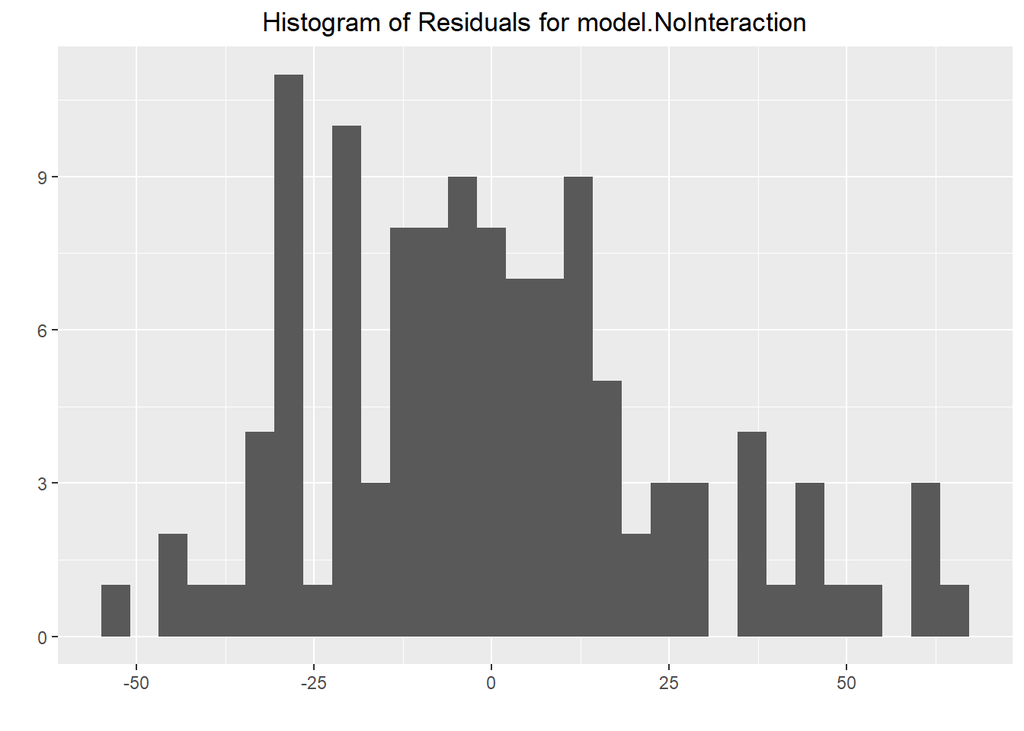

```r
# Data to fit
data_modified_team <- team_data %>%
  select(TeamScore,
         params$dependent_response_team,
         Target,
         SessionOrder,
         Team)

# Plot location
setwd(figure_directory)

# Generate models with variable response
data_focus_team <- data_modified_team
model.NoInteraction <- model_data_Target_Session(df = data_focus_team, dependent =  params$dependent_response_team, model.type =  "NoInteraction", is.team = TRUE, is.robust = FALSE)

# Histogram of Residuals - model.NoInteraction
ggplot(model.NoInteraction, aes(x = .resid)) +
  geom_histogram(bins = 30) +
  labs(title = paste("Histogram of Residuals for model.NoInteraction"), x = "", y = "") +
  theme(plot.title = element_text(hjust = 0.5)) +
  ggsave(filename = paste("Histogram_Residuals_", params$dependent_response_name_NoSpace, "_NoInteraction_Team.png", sep = ""))
```

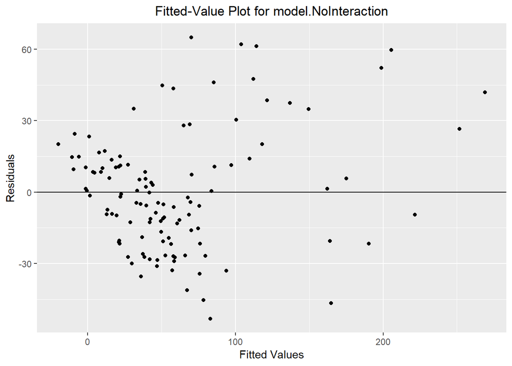

```r
# Fitted values - model.NoInteraction
ggplot(model.NoInteraction, aes(x = .fitted, y = .resid)) +
  geom_point() +
  geom_hline(yintercept = 0)+
  labs(title = paste("Fitted-Value Plot for model.NoInteraction"), x = "Fitted Values", y = "Residuals") +
  theme(plot.title = element_text(hjust = 0.5)) +
  ggsave(filename = paste("FitteValue_Residuals_", params$dependent_response_name_NoSpace, "_NoInteraction_Team.png", sep = ""))
```

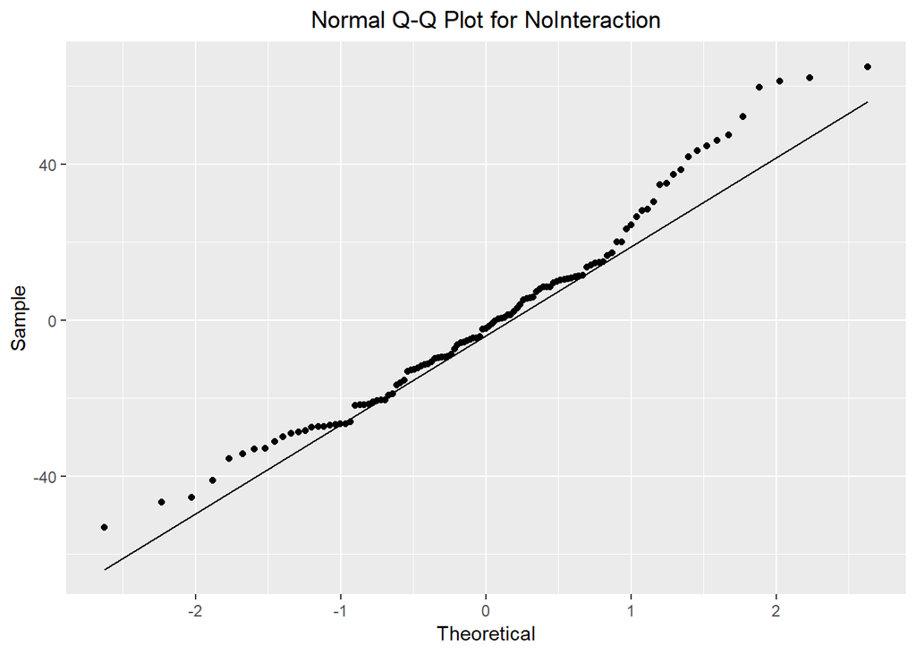

```r
# QQ plots - model.NoInteraction
ggplot(model.NoInteraction, aes(sample = .resid)) +
  stat_qq() +
  stat_qq_line()+
  labs(title = "Normal Q-Q Plot for NoInteraction", x = "Theoretical", y = "Sample") +
   theme(plot.title = element_text(hjust = 0.5)) +
  ggsave(filename = paste("QQ_Residuals_", params$dependent_response_name_NoSpace, "_NoInteraction_Team.png", sep = ""))
```

model.NoInteraction: Visually, it looks like the model violates assumption 2 and 3 in the fitted-value plot and the QQ plot, respectively. I will need to compare this model to a robust model to examine the influence of the apparent violation. If there is a noticeable difference, I will need to transform the data.

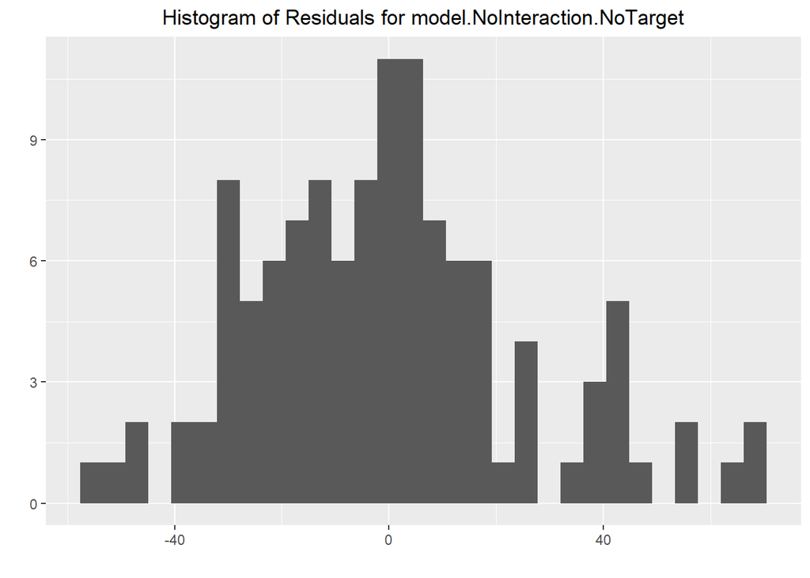

```r
# Data to fit
data_modified_team <- team_data %>%
  select(TeamScore,
         params$dependent_response_team,
         Target,
         SessionOrder,
         Team)

# Plot location
setwd(figure_directory)

# Generate models with variable response

data_focus_team <- data_modified_team
model.NoInteraction.NoTarget <- model_data_Target_Session(df = data_focus_team, dependent =  params$dependent_response_team, model.type =  "NoInteraction_NoTarget", is.team = TRUE, is.robust = FALSE)

# Histogram of Residuals - model.NoInteraction.NoTarget
ggplot(model.NoInteraction.NoTarget, aes(x = .resid)) +
  geom_histogram(bins = 30) +
  labs(title = paste("Histogram of Residuals for model.NoInteraction.NoTarget"), x = "", y = "") +
  theme(plot.title = element_text(hjust = 0.5)) +
  ggsave(filename = paste("Histogram_Residuals_", params$dependent_response_name_NoSpace, "_NoInteraction.NoTarget_Team.png", sep = ""))
```

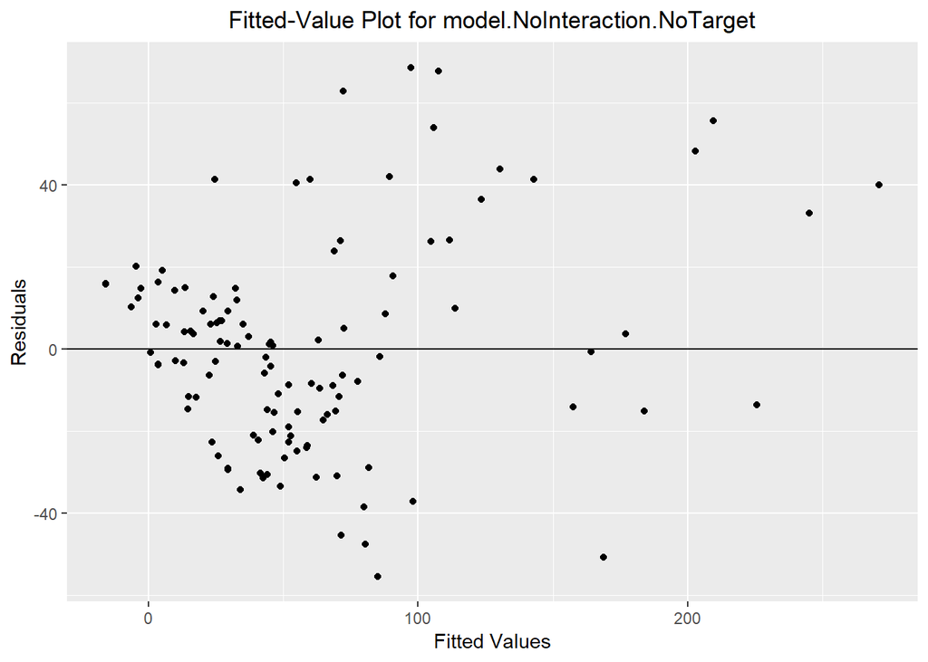

```r
# Fitted values - model.NoInteraction.NoTarget
ggplot(model.NoInteraction.NoTarget, aes(x = .fitted, y = .resid)) +
  geom_point() +
  geom_hline(yintercept = 0)+
  labs(title = paste("Fitted-Value Plot for model.NoInteraction.NoTarget"), x = "Fitted Values", y = "Residuals") +
  theme(plot.title = element_text(hjust = 0.5)) +
  ggsave(filename = paste("FitteValue_Residuals_", params$dependent_response_name_NoSpace, "_NoInteraction.NoTarget_Team.png", sep = ""))
```

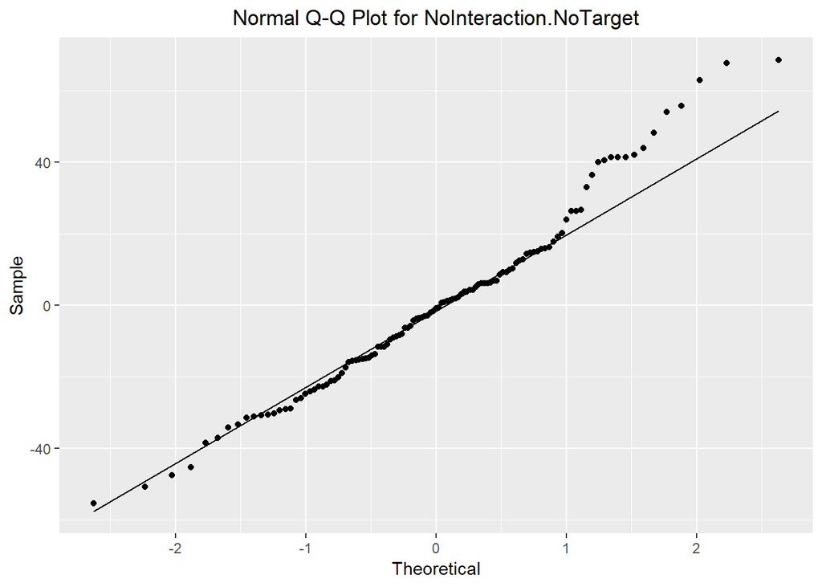

```r
# QQ plots - model.NoInteraction.NoTarget
ggplot(model.NoInteraction.NoTarget, aes(sample = .resid)) +
  stat_qq() +
  stat_qq_line()+
  labs(title = "Normal Q-Q Plot for NoInteraction.NoTarget", x = "Theoretical", y = "Sample") +
   theme(plot.title = element_text(hjust = 0.5)) +
  ggsave(filename = paste("QQ_Residuals_", params$dependent_response_name_NoSpace, "_NoInteraction.NoTarget_Team.png", sep = ""))
```

model.NoInteraction.NoTarget: Visually, it looks like the model violates assumption 2 and 3 in the fitted-value plot and the QQ plot, respectively. I will need to compare this model to a robust model to examine the influence of the apparent violation. If there is a noticeable difference, I will need to transform the data.

**Reflection:** It looks both models violated assumptions 2 and 3. In other words, there may be a constant error violation (i.e., the fitted value plot is not consistent from left to right) and the QQ plot shows an assumption violation. I need to determine if this violation influences the model overall.

##### Q: Does the violation influence the linear model estimation?

I will use the robust estimation for linear mixed models found in the robustlmm package by Koller (2016). I will then compare the robust model to the non-robust model. If the estimated values are noticeably different, then data will need to be transformed.

###### Model.NoInteraction

```r
# Data to fit
data_modified_team <- team_data %>%
  select(TeamScore,
         params$dependent_response_team,
         Target,
         SessionOrder,
         Team)

data_focus_team <- data_modified_team

# Generate robust and non-robust models - NoInteraction
model.NoInteraction <- model_data_Target_Session(df = data_focus_team, dependent =  params$dependent_response_team, model.type =  "NoInteraction", is.team = TRUE, is.robust = FALSE)
rmodel.NoInteraction <- model_data_Target_Session(df = data_focus_team, dependent =  params$dependent_response_team, model.type =  "NoInteraction", is.team = TRUE, is.robust = TRUE)

comparision_results <- compare(model.NoInteraction, rmodel.NoInteraction, show.rho.functions = FALSE)

comparision_results %>%
  kable(caption = "model.NoInteraction") %>%
  kable_styling()
```

model.NoInteraction

|  | model.NoInteraction | rmodel.NoInteraction |
| --- | --- | --- |
| Coef |  |  |
| (Intercept) | 36.32 (10.71) | 27.45 (7.63) |
| TargetInd_Team | -2.04 ( 6.92) | -3.13 (6.21) |
| TargetTeam | 8.57 ( 6.91) | 6.21 (6.20) |
| SessionOrder3 | 19.58 ( 6.91) | 17.68 (6.20) |
| SessionOrder4 | 45.42 ( 6.92) | 39.44 (6.21) |
| VarComp |  |  |
| (Intercept) \| Team | 54.5 | 31.7 |
| sigma | 30.5 | 26.7 |
| REML | 1190 |  |

The robust model.NoInteraction model is noticeably different from the non-robust model.NoInteraction. This suggests that the data should be transformed to satisfy the residual assumptions.

###### Model.NoInteraction.NoTarget

```r
# Data to fit
data_modified_team <- team_data %>%
  select(TeamScore,
         params$dependent_response_team,
         Target,
         SessionOrder,
         Team)

data_focus_team <- data_modified_team

# Generate robust and non-robust models - NoInteraction.NoTarget
model.NoInteraction.NoTarget <- model_data_Target_Session(df = data_focus_team, dependent =  params$dependent_response_team, model.type =  "NoInteraction_NoTarget", is.team = TRUE, is.robust = FALSE)
rmodel.NoInteraction.NoTarget <- model_data_Target_Session(df = data_focus_team, dependent =  params$dependent_response_team, model.type =  "NoInteraction_NoTarget", is.team = TRUE, is.robust = TRUE)

comparision_results <- compare(model.NoInteraction.NoTarget, rmodel.NoInteraction.NoTarget, show.rho.functions = FALSE)

comparision_results %>%
  kable(caption = "model.NoInteraction.NoTarget") %>%
  kable_styling()
```

model.NoInteraction.NoTarget

|  | model.NoInteraction.NoTarget | rmodel.NoInteraction.NoTarget |
| --- | --- | --- |
| Coef |  |  |
| (Intercept) | 38.5 (10.01) | 28.2 (6.74) |
| SessionOrder3 | 19.5 ( 6.94) | 17.9 (6.14) |
| SessionOrder4 | 45.3 ( 6.94) | 39.2 (6.14) |
| VarComp |  |  |
| (Intercept) \| Team | 54.5 | 31.4 |
| sigma | 30.7 | 26.4 |
| REML | 1204 |  |

The robust model.NoInteraction.NoTarget model is noticeably different from the non-robust model.NoInteraction.NoTarget This suggests that the data should be transformed to satisfy the residual assumptions.

**Reflection:** Comparing the normal estimation to the robust models indicates that the data should be transformed because the estimates are noticeably different.

##### Q: Does data transformation satisfy the assumptions of the residuals?

I will use the square root transformation method from Tukey’s ladder (Tukey, 1977).

###### Model.NoInteraction

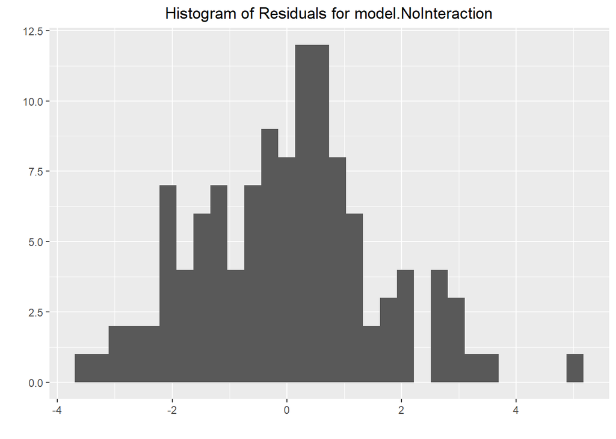

```r
# Data to fit
data_modified_team <- team_data %>%
  select(TeamScore,
         params$dependent_response_team,
         Target,
         SessionOrder,
         Team) %>%
  mutate(sqrt.value = sqrt(.data[[params$dependent_response_team]]))

#response_variable <- "sqrt.value"
data_focus_team <- data_modified_team

#Plot location
setwd(figure_directory)

# Generate non-robust models - NoInteraction
model.NoInteraction <- model_data_Target_Session(df = data_focus_team, dependent =  "sqrt.value", model.type =  "NoInteraction", is.team = TRUE, is.robust = FALSE)

# Histogram of Residuals - model.NoInteraction
ggplot(model.NoInteraction, aes(x = .resid)) +
  geom_histogram(bins = 30) +
  labs(title = paste("Histogram of Residuals for model.NoInteraction"), x = "", y = "") +
  theme(plot.title = element_text(hjust = 0.5)) +
  ggsave(paste("Histogram_Residuals_", params$dependent_response_name_NoSpace, "_sqrt_NoInteraction_Team.png", sep = ""))
```

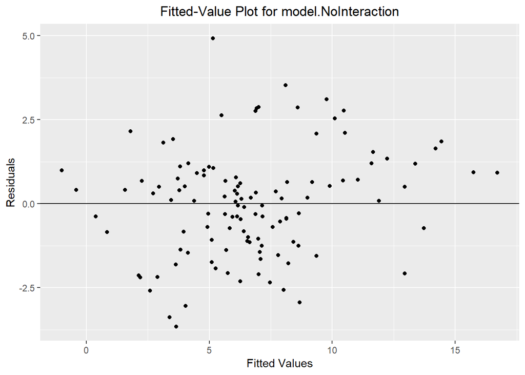

```r
# Fitted values - model.NoInteraction
ggplot(model.NoInteraction, aes(x = .fitted, y = .resid)) +
  geom_point() +
  geom_hline(yintercept = 0)+
  labs(title = paste("Fitted-Value Plot for model.NoInteraction"), x = "Fitted Values", y = "Residuals") +
  theme(plot.title = element_text(hjust = 0.5)) +
  ggsave(paste("FitteValue_Residuals_", params$dependent_response_name_NoSpace, "_sqrt_NoInteraction_Team.png", sep = ""))
```

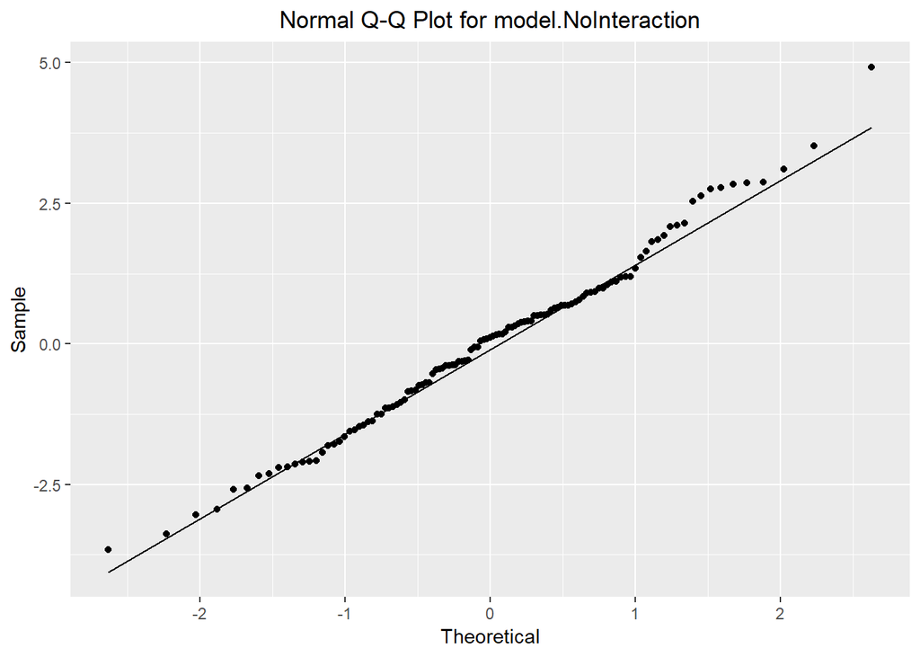

```r
# QQ plots - model.NoInteraction
ggplot(model.NoInteraction, aes(sample = .resid)) +
  stat_qq() +
  stat_qq_line()+
  labs(title = "Normal Q-Q Plot for model.NoInteraction", x = "Theoretical", y = "Sample") +
   theme(plot.title = element_text(hjust = 0.5)) +
  ggsave(paste("QQ_Residuals_", params$dependent_response_name_NoSpace, "_sqrt_NoInteraction_Team.png", sep = ""))
```

The diagnostic plots suggest the transformation has resolved the assumption violations for the model.NoInteraction.

###### Model.NoInteraction.NoTarget

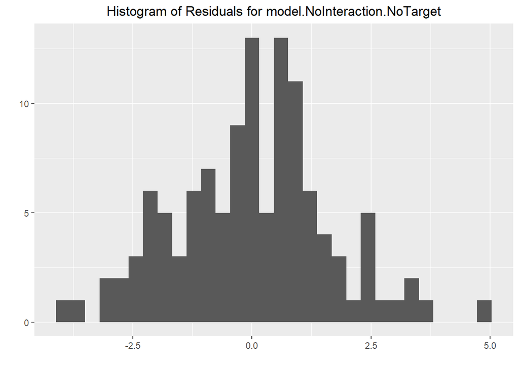

```r
# Data to fit
data_modified_team <- team_data %>%
  select(TeamScore,
         params$dependent_response_team,
         Target,
         SessionOrder,
         Team) %>%
  mutate(sqrt.value = sqrt(.data[[params$dependent_response_team]]))

response_variable <- "sqrt.value"
data_focus_team <- data_modified_team

model.NoInteraction.NoTarget <- model_data_Target_Session(df = data_focus_team, dependent =  "sqrt.value", model.type =  "NoInteraction_NoTarget", is.team = TRUE, is.robust = FALSE)

# Plot location
setwd(figure_directory)

# Histogram of Residuals - model.NoInteraction.NoTarget
ggplot(model.NoInteraction.NoTarget, aes(x = .resid)) +
  geom_histogram(bins = 30) +
  labs(title = paste("Histogram of Residuals for model.NoInteraction.NoTarget"), x = "", y = "") +
  theme(plot.title = element_text(hjust = 0.5)) +
  ggsave(paste("Histogram_Residuals_", params$dependent_response_name_NoSpace, "_sqrt_NoInteraction.NoTarget_Team.png", sep = ""))
```

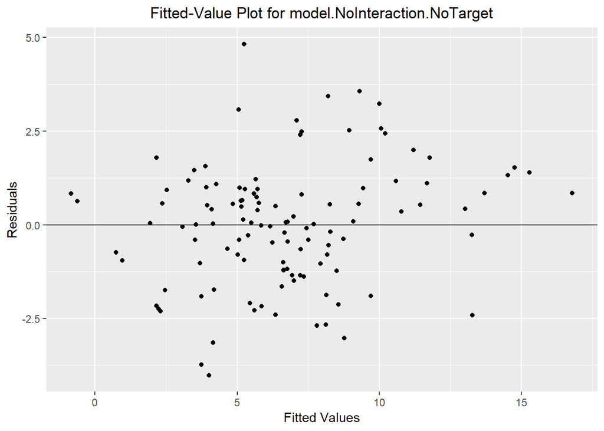

```r
# Fitted values - model.NoInteraction.NoTarget
ggplot(model.NoInteraction.NoTarget, aes(x = .fitted, y = .resid)) +
  geom_point() +
  geom_hline(yintercept = 0)+
  labs(title = paste("Fitted-Value Plot for model.NoInteraction.NoTarget"), x = "Fitted Values", y = "Residuals") +
  theme(plot.title = element_text(hjust = 0.5)) +
  ggsave(paste("FittedValue_Residuals_", params$dependent_response_name_NoSpace, "_sqrt_NoInteraction.NoTarget_Team.png", sep = ""))
```

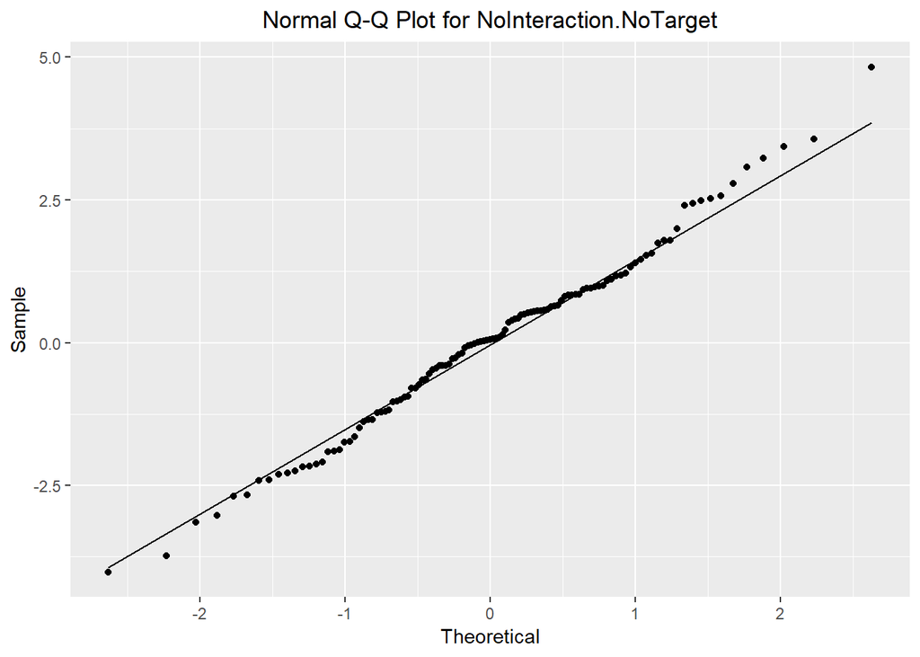

```r
# QQ plots - model.NoInteraction.NoTarget
ggplot(model.NoInteraction.NoTarget, aes(sample = .resid)) +
  stat_qq() +
  stat_qq_line()+
  labs(title = "Normal Q-Q Plot for NoInteraction.NoTarget", x = "Theoretical", y = "Sample") +
   theme(plot.title = element_text(hjust = 0.5)) +
  ggsave(paste("QQ_Residuals_", params$dependent_response_name_NoSpace, "_sqrt_NoInteraction.NoTarget_Team.png", sep = ""))
```

The diagnostic plots suggest the transformation has resolved the assumption violations for the model.NoInteraction.NoTarget.

**Reflection:** The plots suggest that the data transformation resolved the residual assumption violations for both models. I will use a step on Tukey’s ladder to transform the data.

##### Q: Are there any effects that are significant?

I want to determine if Target has a significant effect. I will examine the model itself, and then I will calculate the estimated marginal means to compare all three levels.

###### Model.NoInteraction

```r
# Data to fit
data_modified_team <- team_data %>%
  select(TeamScore,
         params$dependent_response_team,
         Target,
         SessionOrder,
         Team) %>%
  mutate(sqrt.value = sqrt(.data[[params$dependent_response_team]]))

#response_variable <- "sqrt.value"
data_focus_team <- data_modified_team

# Generate robust and non-robust models - NoInteraction
model.NoInteraction <- model_data_Target_Session(df = data_focus_team, dependent =  "sqrt.value", model.type =  "NoInteraction", is.team = TRUE, is.robust = FALSE)

summary(model.NoInteraction)
```

```
## Linear mixed model fit by REML. t-tests use Satterthwaite's method [
## lmerModLmerTest]
## Formula:
## as.formula(paste(dependent, "~ Target + SessionOrder + (1|Team)"))
##    Data: df
##
## REML criterion at convergence: 567.4
##
## Scaled residuals:
##      Min       1Q   Median       3Q      Max
## -1.89904 -0.58108  0.05605  0.47135  2.55849
##
## Random effects:
##  Groups   Name        Variance Std.Dev.
##  Team     (Intercept) 10.520   3.243
##  Residual              3.706   1.925
## Number of obs: 117, groups:  Team, 39
##
## Fixed effects:
##                Estimate Std. Error      df t value Pr(>|t|)
## (Intercept)      5.0281     0.6507 69.1811   7.727 6.22e-11 ***
## TargetInd_Team  -0.2521     0.4365 74.0000  -0.578 0.565256
## TargetTeam       0.5439     0.4361 74.0000   1.247 0.216240
## SessionOrder3    1.5838     0.4361 74.0000   3.632 0.000515 ***
## SessionOrder4    3.0919     0.4365 74.0000   7.084 6.87e-10 ***
## ---
## Signif. codes:  0 '***' 0.001 '**' 0.01 '*' 0.05 '.' 0.1 ' ' 1
##
## Correlation of Fixed Effects:
##             (Intr) TrgI_T TrgtTm SssnO3
## TargtInd_Tm -0.318
## TargetTeam  -0.327  0.500
## SessinOrdr3 -0.327 -0.026 -0.013
## SessinOrdr4 -0.318 -0.051 -0.026  0.500
```

The estimations are in reference to the Ind level for the Target variable and session 2 for the session order variable. The results suggest that session 3 and 4 have a significant effect. I expected this effect. The results also indicate that the impact of the Team and Ind_Team levels do not have an effect that is greater than zero, in reference to the Ind level.

```r
# Data to fit
data_modified_team <- team_data %>%
  select(TeamScore,
         params$dependent_response_team,
         Target,
         SessionOrder,
         Team) %>%
  mutate(sqrt.value = sqrt(.data[[params$dependent_response_team]]))

#response_variable <- "sqrt.value"
data_focus_team <- data_modified_team

# Generate robust and non-robust models - NoInteraction
model.NoInteraction <- model_data_Target_Session(df = data_focus_team, dependent =  "sqrt.value", model.type =  "NoInteraction", is.team = TRUE, is.robust = FALSE)

emmeans(model.NoInteraction, list(pairwise ~ Target), adjust = "tukey")
```

```
## $`emmeans of Target`
##  Target   emmean    SE   df lower.CL upper.CL
##  Ind        6.59 0.604 54.5     5.38     7.80
##  Ind_Team   6.33 0.604 54.5     5.12     7.55
##  Team       7.13 0.604 54.4     5.92     8.34
##
## Results are averaged over the levels of: SessionOrder
## Degrees-of-freedom method: satterthwaite
## Confidence level used: 0.95
##
## $`pairwise differences of Target`
##  contrast        estimate    SE df t.ratio p.value
##  Ind - Ind_Team     0.252 0.436 74  0.578  0.8325
##  Ind - Team        -0.544 0.436 74 -1.247  0.4295
##  Ind_Team - Team   -0.796 0.436 74 -1.825  0.1684
##
## Results are averaged over the levels of: SessionOrder
## P value adjustment: tukey method for comparing a family of 3 estimates
```

The estimated marginal means show no significant difference among the Target variable. It does look like the different between Ind_Team and Team is approaching significance (p = .168). This approaching significance suggests that more data is needed.

```r
# Data to fit
data_modified_team <- team_data %>%
  select(TeamScore,
         params$dependent_response_team,
         Target,
         SessionOrder,
         Team) %>%
  mutate(sqrt.value = sqrt(.data[[params$dependent_response_team]]))

#response_variable <- "sqrt.value"
data_focus_team <- data_modified_team

# Generate robust and non-robust models - NoInteraction
model.NoInteraction <- model_data_Target_Session(df = data_focus_team, dependent =  "sqrt.value", model.type =  "NoInteraction", is.team = TRUE, is.robust = FALSE)

emmeans(model.NoInteraction, list(pairwise ~ SessionOrder), adjust = "tukey")
```

```
## $`emmeans of SessionOrder`
##  SessionOrder emmean    SE   df lower.CL upper.CL
##  2              5.13 0.604 54.5     3.91     6.34
##  3              6.71 0.604 54.4     5.50     7.92
##  4              8.22 0.604 54.5     7.01     9.43
##
## Results are averaged over the levels of: Target
## Degrees-of-freedom method: satterthwaite
## Confidence level used: 0.95
##
## $`pairwise differences of SessionOrder`
##  contrast estimate    SE df t.ratio p.value
##  2 - 3       -1.58 0.436 74 -3.632  0.0015
##  2 - 4       -3.09 0.436 74 -7.084  <.0001
##  3 - 4       -1.51 0.436 74 -3.458  0.0026
##
## Results are averaged over the levels of: Target
## P value adjustment: tukey method for comparing a family of 3 estimates
```

The estimated marginal means show a significant difference between all of the sessions. This significance suggests that the amount of time remaining at the end of the session increased over time. In other words, the teams were getting faster over time.

**Reflection:** The *model.NoInteraction:* model shows no significant effect from the Target levels, but it does show a significant effect from the session order. Specifically, all of the session orders were significantly different from one another. The significance among the session orders means that the amount of time remaining at the end of each session increased over time.

###### Model.NoInteraction.NoTarget

```r
# Data to fit
data_modified_team <- team_data %>%
  select(TeamScore,
         params$dependent_response_team,
         Target,
         SessionOrder,
         Team) %>%
  mutate(sqrt.value = sqrt(.data[[params$dependent_response_team]]))

#response_variable <- "sqrt.value"
data_focus_team <- data_modified_team

# Generate robust and non-robust models - NoInteraction_NoTarget
model.NoInteraction.NoTarget <- model_data_Target_Session(df = data_focus_team, dependent =  "sqrt.value", model.type =  "NoInteraction_NoTarget", is.team = TRUE, is.robust = FALSE)

summary(model.NoInteraction.NoTarget)
```

```
## Linear mixed model fit by REML. t-tests use Satterthwaite's method [
## lmerModLmerTest]
## Formula: as.formula(paste(dependent, "~ SessionOrder + (1|Team)"))
##    Data: df
##
## REML criterion at convergence: 570.9
##
## Scaled residuals:
##      Min       1Q   Median       3Q      Max
## -2.06519 -0.53604  0.02725  0.49172  2.48367
##
## Random effects:
##  Groups   Name        Variance Std.Dev.
##  Team     (Intercept) 10.495   3.240
##  Residual              3.778   1.944
## Number of obs: 117, groups:  Team, 39
##
## Fixed effects:
##               Estimate Std. Error      df t value Pr(>|t|)
## (Intercept)     5.1318     0.6050 54.7708   8.483 1.48e-11 ***
## SessionOrder3   1.5774     0.4402 76.0000   3.584 0.000596 ***
## SessionOrder4   3.0790     0.4402 76.0000   6.995 8.96e-10 ***
## ---
## Signif. codes:  0 '***' 0.001 '**' 0.01 '*' 0.05 '.' 0.1 ' ' 1
##
## Correlation of Fixed Effects:
##             (Intr) SssnO3
## SessinOrdr3 -0.364
## SessinOrdr4 -0.364  0.500
```

The results show that that session 3 and 4 are significantly different from session 2.

```r
# Data to fit
data_modified_team <- team_data %>%
  select(TeamScore,
         params$dependent_response_team,
         Target,
         SessionOrder,
         Team) %>%
  mutate(sqrt.value = sqrt(.data[[params$dependent_response_team]]))

#response_variable <- "sqrt.value"
data_focus_team <- data_modified_team

# Generate robust and non-robust models - NoInteraction_NoTarget
model.NoInteraction.NoTarget <- model_data_Target_Session(df = data_focus_team, dependent =  "sqrt.value", model.type =  "NoInteraction_NoTarget", is.team = TRUE, is.robust = FALSE)

emmeans(model.NoInteraction.NoTarget, list(pairwise ~ SessionOrder), adjust = "tukey")
```

```
## $`emmeans of SessionOrder`
##  SessionOrder emmean    SE   df lower.CL upper.CL
##  2              5.13 0.605 54.8     3.92     6.34
##  3              6.71 0.605 54.8     5.50     7.92
##  4              8.21 0.605 54.8     7.00     9.42
##
## Degrees-of-freedom method: satterthwaite
## Confidence level used: 0.95
##
## $`pairwise differences of SessionOrder`
##  contrast estimate   SE df t.ratio p.value
##  2 - 3       -1.58 0.44 76 -3.584  0.0017
##  2 - 4       -3.08 0.44 76 -6.995  <.0001
##  3 - 4       -1.50 0.44 76 -3.412  0.0029
##
## P value adjustment: tukey method for comparing a family of 3 estimates
```

The results show a significant difference between each session.

**Reflection:** As expected, the results show a significant difference among the session order. In other words, the amount of time remaining at the end of each session increased over time.

##### Summary / Reflection

I had to transform the data to resolve assumption issues. I used one of the steps in the Tukey ladder Tukey (1977). I took the square root of all the values in the time remaining value for the teams.

Overall, the results show no significant effect from the Target variable, but it does show that the session order has a significant impact. This impact means that the amount of time remaining at the end of each session increased over time. I expected the effects of Session Order. There are no statistically significant results that I can discuss about Target.

#### Individual

We learned that **model.NoInteraction** best describe the individual level data(see previous analysis).

```r
# Data to model
data_modified_ind <- ind_data %>%
  select(params$dependent_response_ind,
         Target,
         SessionOrder,
         Team,
         Player_ID)

# Plot location
setwd(figure_directory)

# Generate models with variable response

data_focus_ind <- data_modified_ind
model.NoInteraction <- model_data_Target_Session(df = data_focus_ind, dependent =  params$dependent_response_ind, model.type =  "NoInteraction", is.team = FALSE, is.robust = FALSE)
```

```
## boundary (singular) fit: see ?isSingular
```

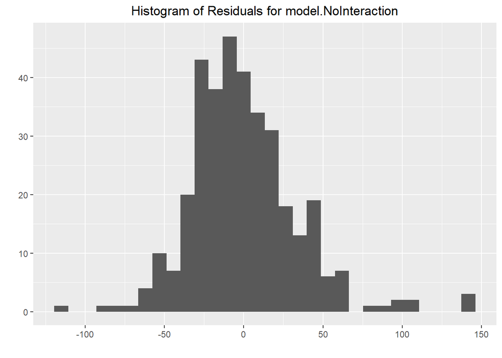

```r
# Histogram of Residuals - model.NoInteraction
ggplot(model.NoInteraction, aes(x = .resid)) +
  geom_histogram(bins = 30) +
  labs(title = paste("Histogram of Residuals for model.NoInteraction"), x = "", y = "") +
  theme(plot.title = element_text(hjust = 0.5)) +
  ggsave(paste("Histogram_Residuals_", params$dependent_response_name_NoSpace, "_NoInteraction_Ind.png", sep =""))
```

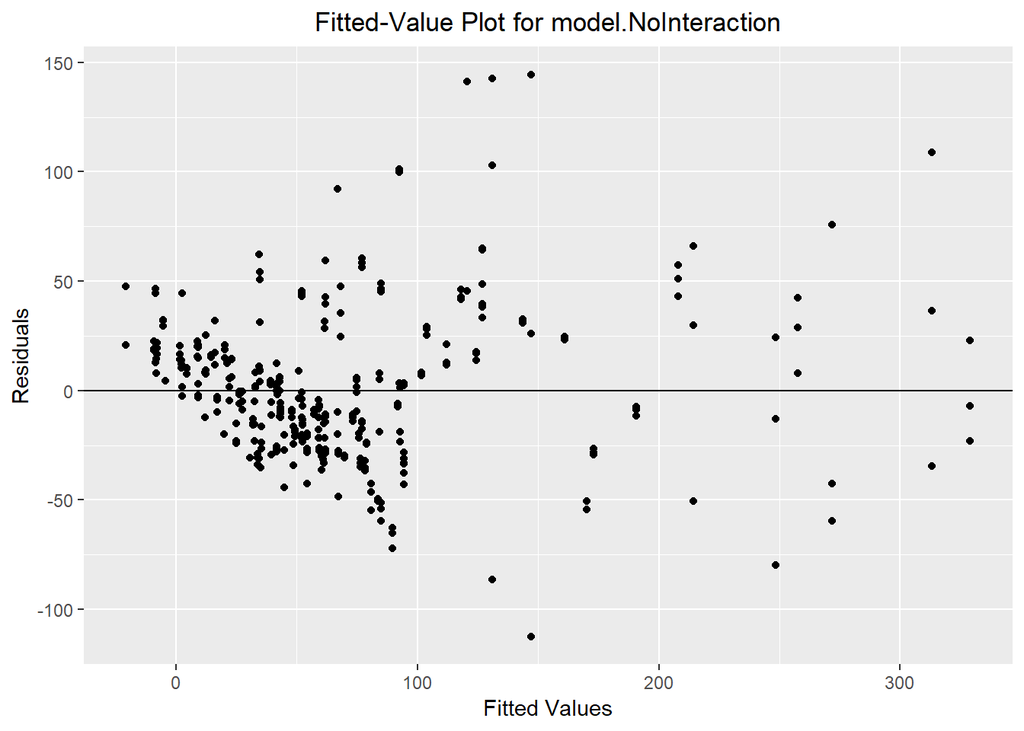

```r
# Fitted values - model.NoInteraction
ggplot(model.NoInteraction, aes(x = .fitted, y = .resid)) +
  geom_point() +
  geom_hline(yintercept = 0)+
  labs(title = paste("Fitted-Value Plot for model.NoInteraction"), x = "Fitted Values", y = "Residuals") +
  theme(plot.title = element_text(hjust = 0.5)) +
  ggsave(paste("FittedValue_Residuals_", params$dependent_response_name_NoSpace, "_NoInteraction_Ind.png", sep =""))
```

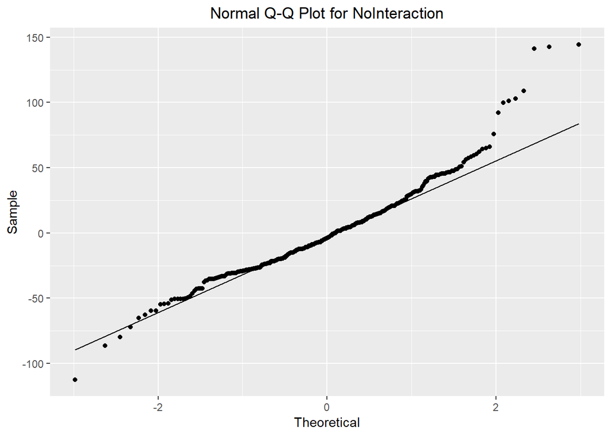

```r
# QQ plots - model.NoInteraction
ggplot(model.NoInteraction, aes(sample = .resid)) +
  stat_qq() +
  stat_qq_line()+
  labs(title = "Normal Q-Q Plot for NoInteraction", x = "Theoretical", y = "Sample") +
   theme(plot.title = element_text(hjust = 0.5)) +
  ggsave(paste("QQ_Residuals_", params$dependent_response_name_NoSpace, "_NoInteraction_Ind.png", sep =""))
```

model.NoInteraction: Visually, it looks like the model violates assumption 2 and 3 in the fitted-value plot and the QQ plot, respectively. I will need to compare this model to a robust model to examine the influence of the apparent violation. If there is a noticeable difference, I will need to transform the data.

**Reflection:** Overall, it looks like I need to compare the model to the robust models to see if the violation has any influence on the model estimation.

##### Q: Does the violation influence the model estimation?

I will use the robust estimation for linear mixed models found in the robustlmm package by Koller (2016). I will then compare the robust model to the non-robust model. If the estimated values are noticeably different, then data will need to be transformed.

```r
# Data to model
data_modified_ind <- ind_data %>%
  select(params$dependent_response_ind,
         Target,
         SessionOrder,
         Team,
         Player_ID)

# Generate models with variable response
data_focus_ind <- data_modified_ind
model.NoInteraction <- model_data_Target_Session(df = data_focus_ind, dependent =  params$dependent_response_ind, model.type =  "NoInteraction", is.team = FALSE, is.robust = FALSE)
```

```
## boundary (singular) fit: see ?isSingular
```

```r
rmodel.NoInteraction <- model_data_Target_Session(df = data_focus_ind, dependent =  params$dependent_response_ind, model.type =  "NoInteraction", is.team = FALSE, is.robust = TRUE)
```

```
## boundary (singular) fit: see ?isSingular
```

```r
comparision_results <- compare(model.NoInteraction, rmodel.NoInteraction, show.rho.functions = FALSE)

comparision_results %>%
  kable(caption = "model.NoInteraction") %>%
  kable_styling()
```

model.NoInteraction

|  | model.NoInteraction | rmodel.NoInteraction |
| --- | --- | --- |
| Coef |  |  |
| (Intercept) | 44.28 (10.92) | 30.87 (6.36) |
| TargetInd_Team | -6.96 ( 4.71) | -3.11 (3.53) |
| TargetTeam | 8.33 ( 4.71) | 6.07 (3.53) |
| SessionOrder3 | 25.91 ( 4.71) | 20.51 (3.53) |
| SessionOrder4 | 50.31 ( 4.71) | 41.93 (3.53) |
| VarComp |  |  |
| (Intercept) \| Player_ID | 0.0 | 0.0 |
| (Intercept) \| Team | 62.9 | 33.5 |
| sigma | 36 | 26.3 |
| REML | 3611 |  |

There is a noticeable difference between the non-robust model and the robust model. This noticeable difference indicates that the data should be transformed to attempt to satisfy the assumptions.

**Reflection:** I need to transform the data because there is a very noticeable difference between the robust model and the non-robust model.

##### Q: Does data transformation satisfy the assumptions of the residuals?

I will use the square root transformation method from Tukey’s ladder (Tukey, 1977).

```r
# Data to model
data_modified_ind <- ind_data %>%
  select(params$dependent_response_ind,
         Target,
         SessionOrder,
         Team,
         Player_ID) %>%
  mutate(sqrt.value = sqrt(ifelse(.data[[params$dependent_response_ind]] < 0, 0, .data[[params$dependent_response_ind]]))) # Some of the time remaining vaules are negative when the should be zero. I want to make sure those values are zero

# Plot location
setwd(figure_directory)

#response_variable <- "sqrt.value"
data_focus_ind <- data_modified_ind

# Generate models with variable response
model.NoInteraction <- model_data_Target_Session(df = data_focus_ind, dependent =  "sqrt.value", model.type =  "NoInteraction", is.team = FALSE, is.robust = FALSE)
```

```
## boundary (singular) fit: see ?isSingular
```

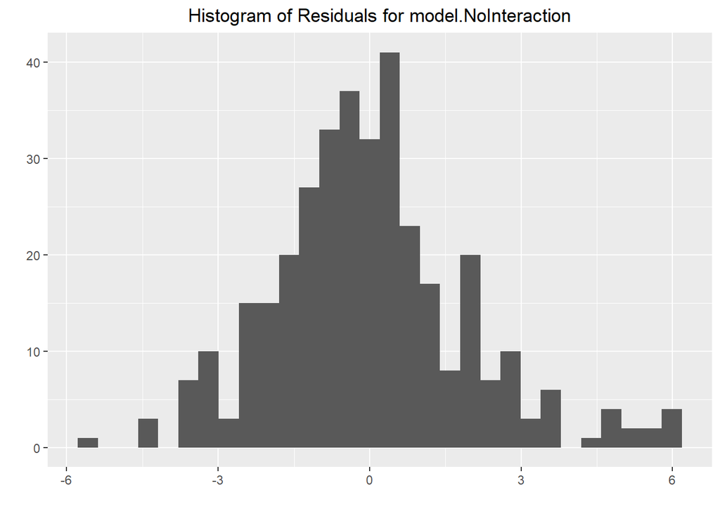

```r
# Histogram of Residuals - model.NoInteraction
ggplot(model.NoInteraction, aes(x = .resid)) +
  geom_histogram(bins = 30) +
  labs(title = paste("Histogram of Residuals for model.NoInteraction"), x = "", y = "") +
  theme(plot.title = element_text(hjust = 0.5)) +
  ggsave(paste("Histogram_Residuals_", params$dependent_response_name_NoSpace, "_sqrt_NoInteraction_Ind.png", sep =""))
```

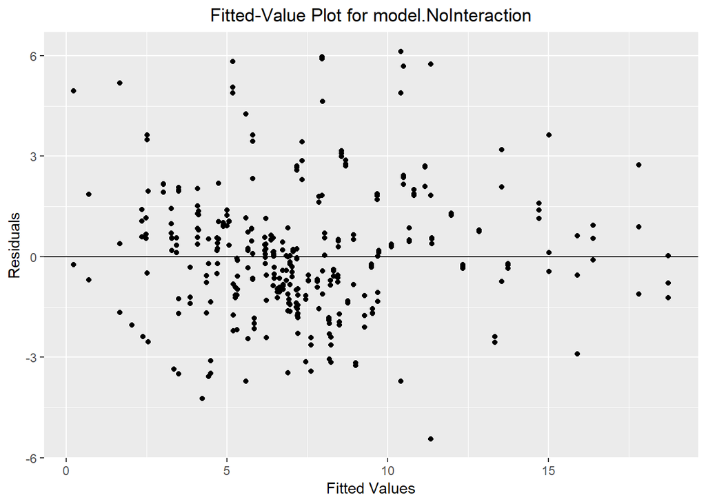

```r
# Fitted values - model.NoInteraction
ggplot(model.NoInteraction, aes(x = .fitted, y = .resid)) +
  geom_point() +
  geom_hline(yintercept = 0)+
  labs(title = paste("Fitted-Value Plot for model.NoInteraction"), x = "Fitted Values", y = "Residuals") +
  theme(plot.title = element_text(hjust = 0.5)) +
  ggsave(paste("FittedValue_Residuals_", params$dependent_response_name_NoSpace, "_sqrt_NoInteraction_Ind.png", sep =""))
```

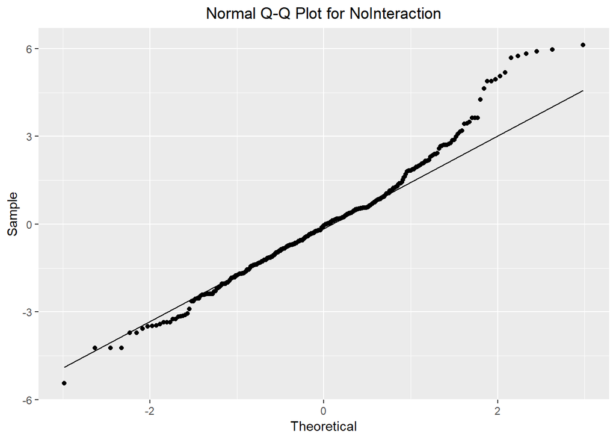

```r
# QQ plots - model.NoInteraction
ggplot(model.NoInteraction, aes(sample = .resid)) +
  stat_qq() +
  stat_qq_line()+
  labs(title = "Normal Q-Q Plot for NoInteraction", x = "Theoretical", y = "Sample") +
  theme(plot.title = element_text(hjust = 0.5)) +
  ggsave(paste("QQ_Residuals_", params$dependent_response_name_NoSpace, "_sqrt_NoInteraction_Ind.png", sep =""))
```

There still appears to be a normality violation in the QQ plot. So, I need to compare the robust and non-robust models to make sure I do not need to worry about this violation.

```r
# Data to model
data_modified_ind <- ind_data %>%
  select(params$dependent_response_ind,
         Target,
         SessionOrder,
         Team,
         Player_ID) %>%
  mutate(sqrt.value = sqrt(ifelse(.data[[params$dependent_response_ind]] < 0, 0, .data[[params$dependent_response_ind]]))) # Some fo the time remaining vaules are negative when the should be zero. I want to make sure those values are zero

#response_variable <- "sqrt.value"
data_focus_ind <- data_modified_ind

# Generate models with variable response
model.NoInteraction <- model_data_Target_Session(df = data_focus_ind, dependent =  "sqrt.value", model.type =  "NoInteraction", is.team = FALSE, is.robust = FALSE)
```

```
## boundary (singular) fit: see ?isSingular
```

```r
rmodel.NoInteraction <- model_data_Target_Session(df = data_focus_ind, dependent =  "sqrt.value", model.type =  "NoInteraction", is.team = FALSE, is.robust = TRUE)
```

```
## boundary (singular) fit: see ?isSingular
```

```r
compare(model.NoInteraction, rmodel.NoInteraction, show.rho.functions = FALSE) %>%
  kable() %>%
  kable_styling()
```

|  | model.NoInteraction | rmodel.NoInteraction |
| --- | --- | --- |
| Coef |  |  |
| (Intercept) | 5.582 (0.580) | 5.150 (0.491) |
| TargetInd_Team | -0.436 (0.269) | -0.242 (0.235) |
| TargetTeam | 0.475 (0.269) | 0.568 (0.234) |
| SessionOrder3 | 1.880 (0.269) | 1.709 (0.234) |
| SessionOrder4 | 3.276 (0.269) | 2.992 (0.235) |
| VarComp |  |  |
| (Intercept) \| Player_ID | 9.92e-09 | 0.00e+00 |
| (Intercept) \| Team | 3.29e+00 | 2.70e+00 |
| sigma | 2.05 | 1.75 |
| REML | 1623 |  |

Comparing the robust and non-robust model does not reveal any concerning difference in estimated value.

**Reflection:** After the transformation, there still appeared to be a violation in the QQ plot but comparing the robust model to the non-robust model showed no concerning differences.

##### Q: Are there any effects that are significant?

```r
# Data to model
data_modified_ind <- ind_data %>%
  select(params$dependent_response_ind,
         Target,
         SessionOrder,
         Team,
         Player_ID) %>%
  mutate(sqrt.value = sqrt(ifelse(.data[[params$dependent_response_ind]] < 0, 0, .data[[params$dependent_response_ind]]))) # Some fo the time remaining vaules are negative when the should be zero. I want to make sure those values are zero

#response_variable <- "sqrt.value"
data_focus_ind <- data_modified_ind

# Generate models with variable response
model.NoInteraction <- model_data_Target_Session(df = data_focus_ind, dependent =  "sqrt.value", model.type =  "NoInteraction", is.team = FALSE, is.robust = FALSE)
```

```
## boundary (singular) fit: see ?isSingular
```

```r
summary(model.NoInteraction)
```

```
## Linear mixed model fit by REML. t-tests use Satterthwaite's method [
## lmerModLmerTest]
## Formula:
## as.formula(paste(dependent, "~ Target + SessionOrder + (1|Team) + (1| Player_ID)"))
##    Data: df
##
## REML criterion at convergence: 1623.4
##
## Scaled residuals:
##      Min       1Q   Median       3Q      Max
## -2.64682 -0.59774 -0.02397  0.44485  2.98641
##
## Random effects:
##  Groups    Name        Variance  Std.Dev.
##  Player_ID (Intercept) 9.843e-17 9.921e-09
##  Team      (Intercept) 1.085e+01 3.294e+00
##  Residual              4.215e+00 2.053e+00
## Number of obs: 351, groups:  Player_ID, 117; Team, 39
##
## Fixed effects:
##                Estimate Std. Error       df t value Pr(>|t|)
## (Intercept)      5.5824     0.5801  50.9214   9.622 4.79e-13 ***
## TargetInd_Team  -0.4357     0.2688 308.0000  -1.621   0.1061
## TargetTeam       0.4750     0.2685 308.0000   1.769   0.0779 .
## SessionOrder3    1.8795     0.2685 308.0000   7.000 1.61e-11 ***
## SessionOrder4    3.2765     0.2688 308.0000  12.190  < 2e-16 ***
## ---
## Signif. codes:  0 '***' 0.001 '**' 0.01 '*' 0.05 '.' 0.1 ' ' 1
##
## Correlation of Fixed Effects:
##             (Intr) TrgI_T TrgtTm SssnO3
## TargtInd_Tm -0.220
## TargetTeam  -0.226  0.500
## SessinOrdr3 -0.226 -0.026 -0.013
## SessinOrdr4 -0.220 -0.051 -0.026  0.500
## convergence code: 0
## boundary (singular) fit: see ?isSingular
```

The results showed a significant effect from session 3 and 4 when compared to session 2. This significant effect is expected. The results showed no significant impact from Target levels when compared to the Ind level. However, it is important to note that the effect from the Team Target level is approaching significance (p = .0779). This suggests that more data is needed to reach significance.

```r
# Data to model
data_modified_ind <- ind_data %>%
  select(params$dependent_response_ind,
         Target,
         SessionOrder,
         Team,
         Player_ID) %>%
  mutate(sqrt.value = sqrt(ifelse(.data[[params$dependent_response_ind]] < 0, 0, .data[[params$dependent_response_ind]]))) # Some fo the time remaining vaules are negative when the should be zero. I want to make sure those values are zero

#response_variable <- "sqrt.value"
data_focus_ind <- data_modified_ind

# Generate models with variable response
model.NoInteraction <- model_data_Target_Session(df = data_focus_ind, dependent =  "sqrt.value", model.type =  "NoInteraction", is.team = FALSE, is.robust = FALSE)
```

```
## boundary (singular) fit: see ?isSingular
```

```r
emmeans(model.NoInteraction, list(pairwise ~ Target), adjust = "tukey")
```

```
## $`emmeans of Target`
##  Target   emmean    SE   df lower.CL upper.CL
##  Ind        7.30 0.561 44.5     6.17     8.43
##  Ind_Team   6.87 0.561 44.5     5.74     8.00
##  Team       7.78 0.561 44.5     6.65     8.91
##
## Results are averaged over the levels of: SessionOrder
## Degrees-of-freedom method: satterthwaite
## Confidence level used: 0.95
##
## $`pairwise differences of Target`
##  contrast        estimate    SE  df t.ratio p.value
##  Ind - Ind_Team     0.436 0.269 308  1.621  0.2383
##  Ind - Team        -0.475 0.269 308 -1.769  0.1818
##  Ind_Team - Team   -0.911 0.269 308 -3.392  0.0023
##
## Results are averaged over the levels of: SessionOrder
## P value adjustment: tukey method for comparing a family of 3 estimates
```

The results show a *significant difference* between the Ind_Team and Team level of feedback. The difference indicates that the amount of time remaining in the Team feedback condition results in higher time remaining (transformed using 1/2 power).

```r
# Data to model
data_modified_ind <- ind_data %>%
  select(params$dependent_response_ind,
         Target,
         SessionOrder,
         Team,
         Player_ID) %>%
  mutate(sqrt.value = sqrt(ifelse(.data[[params$dependent_response_ind]] < 0, 0, .data[[params$dependent_response_ind]]))) # Some fo the time remaining vaules are negative when the should be zero. I want to make sure those values are zero

#response_variable <- "sqrt.value"
data_focus_ind <- data_modified_ind

# Generate models with variable response
model.NoInteraction <- model_data_Target_Session(df = data_focus_ind, dependent =  "sqrt.value", model.type =  "NoInteraction", is.team = FALSE, is.robust = FALSE)
```

```
## boundary (singular) fit: see ?isSingular
```

```r
emmeans(model.NoInteraction, list(pairwise ~ SessionOrder), adjust = "tukey")
```

```
## $`emmeans of SessionOrder`
##  SessionOrder emmean    SE   df lower.CL upper.CL
##  2              5.60 0.561 44.5     4.47     6.73
##  3              7.48 0.561 44.5     6.35     8.60
##  4              8.87 0.561 44.5     7.74    10.00
##
## Results are averaged over the levels of: Target
## Degrees-of-freedom method: satterthwaite
## Confidence level used: 0.95
##
## $`pairwise differences of SessionOrder`
##  contrast estimate    SE  df t.ratio p.value
##  2 - 3       -1.88 0.269 308  -7.000 <.0001
##  2 - 4       -3.28 0.269 308 -12.190 <.0001
##  3 - 4       -1.40 0.269 308  -5.203 <.0001
##
## Results are averaged over the levels of: Target
## P value adjustment: tukey method for comparing a family of 3 estimates
```

There is a significant difference between each of the sessions. This result means that the time remaining at the end of the session was increasing over time. This increase in time remaining suggests that the teams were moving through the session faster the more times they completed the task (Note: This is when the data is transformed using the 1/2 power).

##### Summary / Reflection

There was a **significant difference** between the Ind_Team and Team level feedback condition in **model.NoInteraction**. The significant difference indicates that the amount of time remaining at the end of the session in the Team feedback condition is higher than the amount of time remaining in the Ind_Team condition.

According to the data, giving groups feedback that contains team performance metrics will encourage them to move through the task faster. The amount of time remaining at the end of the session does not tell me if the groups in the Team condition are accurate (i.e., able to collected correct items quicker) as they are completing the task. A plausible conclusion could be that the groups in the Team condition are merely moving through the session quicker than those in the Ind_Team condition.

# References

Field, A. P., & Wilcox, R. R. (2017). Robust statistical methods: A primer for clinical psychology and experimental psychopathology researchers. *Behaviour Research and Therapy*, *98*, 19–38. https://doi.org/10.1016/j.brat.2017.05.013

Galwey, N. W. (2014). Testing the assumptions of the analyses: Inspection of the residual values. In *Introduction to mixed modelling: Beyond regression and analysis of variance* (Second). Chichester, United Kingdom: John Wiley & Sons, Ltd.

Johnson, P. C. (2014). Extension of Nakagawa & Schielzeth’s R 2 GLMM to random slopes models. *Methods in Ecology and Evolution*, *5*(9), 944–946. https://doi.org/10.1111/2041-210X.12225

Koller, M. (2016). robustlmm : An R Package for Robust Estimation of Linear Mixed-Effects Models. *Journal of Statistical Software*, *75*(6). https://doi.org/10.18637/jss.v075.i06

Nakagawa, S., & Schielzeth, H. (2013). A general and simple method for obtaining R 2 from generalized linear mixed-effects models. *Methods in Ecology and Evolution*, *4*(2), 133–142. https://doi.org/10.1111/j.2041-210x.2012.00261.x

Tukey, J. W. (1977). *Exploratory data analysis*. Reading, Mass.: Addison-Wesley Pub.